# Rating Pricing Study: Is a 0.4-Star Difference Worth More in the 4s Than in the 3s?

Author

Jamie C. Lee

Published

November 11, 2026

# Overview

Participants saw two options that were identical except for their average customer rating, which differed by 0.4 stars. One option had a $55 price, and participants entered the price for the other option that would make them indifferent between the two. The design was 2 × 2 × 2 × 2 between subjects:

- **Product:** wireless earbuds or an internet service provider (ISP).
- **Rating level:** 3.4 vs. 3.8 (“3s”) or 4.4 vs. 4.8 (“4s”).
- **Direction:** *going up* means the lower-rated option had the $55 price, so participants priced the higher-rated one. *Going down* means the higher-rated option had the $55 price, so participants priced the lower-rated one.
- **Position order:** whether the lower-rated option was shown as A (left) or B (right).

**Questions:**

1. Does position order matter (whether the lower-rated option was shown first, as A, or second, as B)? If not, collapse across it.
2. Do earbuds and ISPs give the same results? Every comparison below is run for each product separately, and the two are pooled only if they match.
3. Is the premium for a 0.4-star difference different in the 3s vs. the 4s? Tested separately for going up and going down.
4. Is the premium different going up vs. going down? Tested separately for the 3s and the 4s.
5. Do the conclusions hold in raw dollars, and does the price distribution justify logging?

# Key findings

## What this study shows

1. **Being near the top of the scale raises what people will pay to upgrade, but not what they demand to accept a downgrade.** Going up, the 4s gap is worth about 24% more than the 3s gap (11.0% vs. 8.8%). Going down, it is worth no more (26.8% vs. 28.1%). The difference between directions is a significant rating level × direction interaction (p = .008). This is the novel finding.
2. **Giving up a better rating costs 2.4–3.2 times more than gaining one is worth.** This is loss aversion applied to ratings. The principle is not new, but its size for ratings matters practically.
3. **The upgrade effect comes from how much people pay, not how many care.** The share who would pay anything for the better rating is the same in the 3s and 4s (70.8% vs. 71.3%). Among those who would, the 4s premium is larger (p < .001).
4. **The value of a star depends on how you ask.** Estimates differ by a factor of 2–3 between the upgrade and downgrade framings. That is a warning for anyone measuring the value of ratings with surveys or conjoint analysis.

**Positioning.** Rating differences near the top of the scale *feel* larger (mixed-design study). This study shows that the extra value reaches prices only when consumers consider upgrading. When they consider giving up a better rating, the value is large but insensitive to where on the scale the difference sits. Put briefly: **upgrade valuations are sensitive to where a rating difference falls on the scale; downgrade valuations are not.** See Proposed path forward.

## Details

- **Sample:** 4203 participants after excluding 245 response coherence violations (wrong-direction answers) and 328 who read the scenario faster than skimming speed.
- **Position order (A/B) doesn’t matter.** There is no main effect and no interaction with the other factors, so the analyses collapse across order.
- **Going up, a 0.4-star gap is worth more in the 4s than in the 3s.** People would pay about 11.0% more for the higher-rated option in the 4s vs. 8.8% in the 3s (0.019 log points, p < .001).
- **Going down, it isn’t.** The required discount is similar in the 3s and 4s (-0.011 log points, p = .267). So the 3s-vs-4s difference depends on direction, a significant rating level × direction interaction (b = -0.029, p = .008). The 0.4-star gap is worth more in the 4s when people pay for an upgrade, but not when they ask for a discount to accept a downgrade.
- **Giving up a better rating costs much more than gaining one is worth.** Going down, the lower-rated option had to be about 22% (3s) or 21% (4s) cheaper. Going up, the higher-rated option was worth only about 9% to 11% more. As premiums, the going-down premium is 2.4 to 3.2 times the going-up premium (all p < .001). This fits loss aversion.
- **Many people wouldn’t pay anything for the better rating.** 29% of going-up participants entered exactly $55, vs. 6% going down. The asymmetry holds both in who values the gap and in how much those people value it. The 4s advantage going up comes from larger premiums among people who value the gap (0.026 log points, p < .001), not from more people valuing it (70.8% vs. 71.3%).
- **Earbuds and ISPs show the same pattern.** ISP premiums are smaller across the board (0.059 log points lower, p < .001), but the effects point the same way and are proportionally similar. The only significant product difference is in the size of the up-vs-down gap in the 3s.
- **Exploratory: review-reading frequency.** Going up, the 4s advantage appears among people who read reviews often or always but not among infrequent readers, matching how big the gap *feels* in an earlier perception study. The trend test is not significant. Frequent readers also demand much larger discounts going down.
- **The results are robust.** They hold in raw dollars, without the extreme prices, under stricter and looser reading-speed cutoffs, with wrong-direction answers kept in, and within each position order. Logging does not make the data more normal; it is used because it measures the premium proportionally in both directions.
- **For marketers:** a 0.4-star advantage lets a brand charge only about 9–11% more, but forces a worse-rated competitor to be about 21–22% cheaper to compete. Ratings protect more than they price.

# Data dictionary

The analysis file is `rating_pricing_study_11.10.26_clean.csv` (one row per participant, N = 4776).

**NoteShow data dictionary**

Built by `clean_rating_pricing.R` from the `raw_data` sheet of `rating_pricing_study_11.10.26.xlsx`. Qualtrics exported the values as numeric codes. The script:

- **Removes rows:** responses whose Prolific ID has no matching Prolific submission (ID list in `Sheet1`, column `Prolific`), and all responses from Prolific IDs with more than one response. This reproduces the hand-cleaned `clean_data` sheet exactly.
- **Combines the earbuds and ISP columns:** for example, `match_price_earbuds` and `match_price_isp` become `wtp`.
- **Adds derived variables and flags.**
- **Drops columns:** columns that were constant for everyone (Status = real response, Finished = 1, Progress = 100, both consent boxes checked, price shown = $55), empty panel fields, `date_created` (the survey build date, not the response date), and identifying fields (IP address, location).

```r
dict <- tribble(
  ~Group, ~Variable, ~Description, ~Values,
  "IDs", "ResponseId", "Qualtrics response ID (unique key)", "Text",
  "IDs", "PROLIFIC_PID, STUDY_ID, SESSION_ID", "Prolific IDs", "Identifying: remove before sharing",
  "Timing", "StartDate, EndDate", "Survey start and end time", "YYYY-MM-DD HH:MM:SS (Qualtrics account time zone)",
  "Timing", "duration", "Total time on the survey", "Seconds",
  "Timing", "page_time", "Time on the scenario + price page before clicking Next", "Seconds",
  "Timing", "first_click, last_click", "Time of the first and last click on the scenario page", "Seconds (0 = no click)",
  "Timing", "click_ct", "Number of clicks on the scenario page", "Count",
  "Timing", "page_words", "Words on the scenario + price page (scenario text, table and question)", "123 (earbuds), 133 (ISP)",
  "Design", "cond", "Cell of the 16-cell design (randomizer, even presentation)", "1–16",
  "Design", "product", "Product in the scenario", "earbuds, isp",
  "Design", "rating_level", "Rating pair shown", "low = 3.4 vs 3.8; high = 4.4 vs 4.8",
  "Design", "direction", "Which option participants priced", "up = priced the higher-rated option (lower-rated shown at $55); down = priced the lower-rated option (higher-rated shown at $55)",
  "Design", "priced_option", "Which option showed the $55 price (same information as direction)", "lower_rated (= up), higher_rated (= down)",
  "Design", "position_order", "Which option appeared as A (left column)", "lower_first = lower-rated is A; higher_first = higher-rated is A",
  "Design", "target_label", "Label of the option participants priced (the one showing \"?\")", "A, B",
  "Design", "priced_label", "Label of the option showing $55", "A, B",
  "Design", "rating_a, rating_b", "Rating shown for Option A and Option B", "3.4, 3.8, 4.4, 4.8",
  "Design", "rating_priced, rating_target", "Rating of the $55 option and of the option participants priced", "3.4, 3.8, 4.4, 4.8",
  "Outcome", "wtp", "Price entered for the target option (earbuds: total price; ISP: monthly price)", "Dollars",
  "Outcome", "p_high, p_low", "Price of the higher- and lower-rated option; one of them is always 55", "Dollars",
  "Outcome", "log_premium", "log(p_high + 1) − log(p_low + 1). The value of the 0.4-star difference, on the same scale for going up and going down; the +1 keeps $0 answers", "0 = no premium; 0.10 ≈ 10.5% premium; negative = lower-rated preferred",
  "Outcome", "dollar_premium", "p_high − p_low: the same premium in raw dollars (used to check the log results)", "Dollars (ISP: per month)",
  "Survey item", "review_freq", "How often do you read online customer reviews before making a purchase?", "1 = Never, 2 = Rarely, 3 = Sometimes, 4 = Often, 5 = Always",
  "Exclusion flags", "too_fast", "Less time on the scenario page than skimming its words at 450 wpm (page_time < page_words / 450 × 60): under 16.4 s for earbuds, 17.7 s for ISP", "1 = flagged, 0 = not",
  "Exclusion flags", "wrong_direction", "Answer puts a lower value on the better-rated option (going up: WTP < $55; going down: WTP > $55)", "1 = flagged, 0 = not",
  "Exclusion flags", "keep", "Primary analysis sample: too_fast = 0 and wrong_direction = 0", "1 = keep, 0 = exclude",
  "Sensitivity flags", "fast_scan", "Faster than 650 wpm (scanning rate; more lenient than too_fast): under 11.4 s earbuds, 12.3 s ISP", "1 = flagged, 0 = not",
  "Sensitivity flags", "fast_read", "Faster than 300 wpm (normal reading rate; stricter than too_fast): under 24.6 s earbuds, 26.6 s ISP", "1 = flagged, 0 = not",
  "Sensitivity flags", "extreme_price", "WTP below $5.50 or above $550 (less than 1/10 or more than 10× the $55 anchor)", "1 = flagged, 0 = not",
  "Sensitivity flags", "ip_dup", "IP address shared with at least one other response (could be a shared network)", "1 = flagged, 0 = not"
)
kbl2(dict) |> column_spec(2, monospace = TRUE) |> collapse_rows(1, valign = "top")
```

| Group | Variable | Description | Values |
| --- | --- | --- | --- |
| IDs | ResponseId | Qualtrics response ID (unique key) | Text |
|  | PROLIFIC_PID, STUDY_ID, SESSION_ID | Prolific IDs | Identifying: remove before sharing |
| Timing | StartDate, EndDate | Survey start and end time | YYYY-MM-DD HH:MM:SS (Qualtrics account time zone) |
|  | duration | Total time on the survey | Seconds |
|  | page_time | Time on the scenario + price page before clicking Next | Seconds |
|  | first_click, last_click | Time of the first and last click on the scenario page | Seconds (0 = no click) |
|  | click_ct | Number of clicks on the scenario page | Count |
|  | page_words | Words on the scenario + price page (scenario text, table and question) | 123 (earbuds), 133 (ISP) |
| Design | cond | Cell of the 16-cell design (randomizer, even presentation) | 1–16 |
|  | product | Product in the scenario | earbuds, isp |
|  | rating_level | Rating pair shown | low = 3.4 vs 3.8; high = 4.4 vs 4.8 |
|  | direction | Which option participants priced | up = priced the higher-rated option (lower-rated shown at $55); down = priced the lower-rated option (higher-rated shown at $55) |
|  | priced_option | Which option showed the $55 price (same information as direction) | lower_rated (= up), higher_rated (= down) |
|  | position_order | Which option appeared as A (left column) | lower_first = lower-rated is A; higher_first = higher-rated is A |
|  | target_label | Label of the option participants priced (the one showing "?") | A, B |
|  | priced_label | Label of the option showing $55 | A, B |
|  | rating_a, rating_b | Rating shown for Option A and Option B | 3.4, 3.8, 4.4, 4.8 |
|  | rating_priced, rating_target | Rating of the $55 option and of the option participants priced | 3.4, 3.8, 4.4, 4.8 |
| Outcome | wtp | Price entered for the target option (earbuds: total price; ISP: monthly price) | Dollars |
|  | p_high, p_low | Price of the higher- and lower-rated option; one of them is always 55 | Dollars |
|  | log_premium | log(p_high + 1) − log(p_low + 1). The value of the 0.4-star difference, on the same scale for going up and going down; the +1 keeps $0 answers | 0 = no premium; 0.10 ≈ 10.5% premium; negative = lower-rated preferred |
|  | dollar_premium | p_high − p_low: the same premium in raw dollars (used to check the log results) | Dollars (ISP: per month) |
| Survey item | review_freq | How often do you read online customer reviews before making a purchase? | 1 = Never, 2 = Rarely, 3 = Sometimes, 4 = Often, 5 = Always |
| Exclusion flags | too_fast | Less time on the scenario page than skimming its words at 450 wpm (page_time < page_words / 450 × 60): under 16.4 s for earbuds, 17.7 s for ISP | 1 = flagged, 0 = not |
|  | wrong_direction | Answer puts a lower value on the better-rated option (going up: WTP < $55; going down: WTP > $55) | 1 = flagged, 0 = not |
|  | keep | Primary analysis sample: too_fast = 0 and wrong_direction = 0 | 1 = keep, 0 = exclude |
| Sensitivity flags | fast_scan | Faster than 650 wpm (scanning rate; more lenient than too_fast): under 11.4 s earbuds, 12.3 s ISP | 1 = flagged, 0 = not |
|  | fast_read | Faster than 300 wpm (normal reading rate; stricter than too_fast): under 24.6 s earbuds, 26.6 s ISP | 1 = flagged, 0 = not |
|  | extreme_price | WTP below $5.50 or above $550 (less than 1/10 or more than 10× the $55 anchor) | 1 = flagged, 0 = not |
|  | ip_dup | IP address shared with at least one other response (could be a shared network) | 1 = flagged, 0 = not |

# Data cleaning

The clean file has one row per participant. Two kinds of responses are excluded from the primary analysis: answers that contradict the task (response coherence violations) and pages read too fast to take in. Responses with extreme prices are kept.

```r
n_rm_dup <- 2   # printed by clean_rating_pricing.R
excl_tab <- tibble(
  Step = c("Responses with a matching Prolific submission",
           "Removed: duplicate Prolific ID (both responses)",
           "Clean file",
           "Excluded: response coherence violation (wrong-direction answer)",
           "Excluded: read faster than 450 wpm (not already excluded)",
           "Primary analysis sample"),
  N = c(nrow(d_all) + n_rm_dup, -n_rm_dup, nrow(d_all),
        -sum(d_all$wrong_direction),
        -sum(d_all$too_fast == 1 & d_all$wrong_direction == 0),
        nrow(d))
)
kbl2(excl_tab)
```

| Step | N |
| --- | --- |
| Responses with a matching Prolific submission | 4778 |
| Removed: duplicate Prolific ID (both responses) | -2 |
| Clean file | 4776 |
| Excluded: response coherence violation (wrong-direction answer) | -245 |
| Excluded: read faster than 450 wpm (not already excluded) | -328 |
| Primary analysis sample | 4203 |

## Exclusion 1: response coherence violations (wrong-direction answers)

The task asks for the price that makes two options identical except for their rating equally attractive. A coherent answer gives the higher-rated option a price at least as high as the lower-rated one. A **wrong-direction** answer does the opposite, putting a lower value on the better-rated option:

- **Going up:** entering less than $55 for the higher-rated option.
- **Going down:** entering more than $55 for the lower-rated option.

Answering exactly $55 (no premium) is coherent and is kept. Counts below are out of the clean file (N = 4776), before any other exclusion.

```r
wd_rows <- d_all |>
  group_by(Direction = as.character(dir), `Rating level` = as.character(level)) |>
  summarise(N = n(), `Wrong direction` = sum(wrong_direction), .groups = "drop")
wd_sub <- d_all |>
  group_by(Direction = as.character(dir)) |>
  summarise(`Rating level` = "Both", N = n(), `Wrong direction` = sum(wrong_direction))
wd_tot <- d_all |>
  summarise(Direction = "Total", `Rating level` = "", N = n(), `Wrong direction` = sum(wrong_direction))
wd <- bind_rows(wd_rows, wd_sub, wd_tot) |>
  mutate(Direction = factor(Direction, c("Going up", "Going down", "Total"))) |>
  arrange(Direction, `Rating level` == "Both") |>
  mutate(`%` = pct(`Wrong direction` / N),
         `By product (earbuds / ISP)` = purrr::map2_chr(as.character(Direction), `Rating level`, function(dr, lv) {
           x <- d_all
           if (dr != "Total") x <- filter(x, as.character(dir) == dr)
           if (!lv %in% c("Both", "")) x <- filter(x, as.character(level) == lv)
           paste(sum(x$wrong_direction[x$product == "Earbuds"]), "/", sum(x$wrong_direction[x$product == "ISP"]))
         }))
kbl2(wd) |> row_spec(which(wd$`Rating level` %in% c("Both", "")), bold = TRUE)
```

| Direction | Rating level | N | Wrong direction | % | By product (earbuds / ISP) |
| --- | --- | --- | --- | --- | --- |
| Going up | 3s (3.4 vs 3.8) | 1196 | 109 | 9.1% | 59 / 50 |
| Going up | 4s (4.4 vs 4.8) | 1193 | 105 | 8.8% | 48 / 57 |
| Going up | Both | 2389 | 214 | 9.0% | 107 / 107 |
| Going down | 3s (3.4 vs 3.8) | 1190 | 17 | 1.4% | 9 / 8 |
| Going down | 4s (4.4 vs 4.8) | 1197 | 14 | 1.2% | 11 / 3 |
| Going down | Both | 2387 | 31 | 1.3% | 20 / 11 |
| Total |  | 4776 | 245 | 5.1% | 127 / 118 |

```r
wd_up <- mean(d_all$wrong_direction[d_all$direction == "up"])
wd_dn <- mean(d_all$wrong_direction[d_all$direction == "down"])
```

Wrong-direction answers are 6.90 times as common going up (9.0%) as going down (1.3%). They are about equally common in the 3s and the 4s, and for earbuds and ISPs. Most going-up violations are round amounts just under $55 ($50, $45, $40), which looks like lowering the price to make the better option “attractive” rather than inattention.

**WarningThis exclusion removes more people going up**

Excluding wrong-direction answers removes 9.0% of going-up participants but only 1.3% of going-down participants. The remaining going-up and going-down groups are therefore not fully comparable random samples. That matters most for Step 3 (up vs. down). The 3s-vs-4s comparisons in Step 2 are within a direction, where exclusion rates are balanced, so they are less affected. Robustness shows every comparison with the wrong-direction answers kept in.

## Exclusion 2: reading speed

Participants are excluded if they left the scenario page faster than it can be skimmed. The page has 123 words for earbuds and 133 for ISPs, counting the scenario text, the table and the question.

- **Typical reading:** Brysbaert’s (2019) meta-analysis of 190 studies puts adult silent reading of English non-fiction at 238 words per minute on average, with most adults between 175 and 300 wpm.
- **Carver’s (1992) reading “gears”** (as summarized by Brysbaert, 2019): normal reading for understanding about 300 wpm, *skimming* for ideas about 450 wpm, and *scanning* for specific words about 650 wpm.
- **The cutoff:** faster than the skimming rate (450 wpm), meaning under 16.4 s for earbuds and 17.7 s for ISPs. Anyone faster than this cannot have taken in the page’s content, even by skimming.
- **This is conservative.** Page time also includes typing an answer, so real reading time is shorter than the timer shows.
- **For comparison:** in web-survey research, Zhang and Conrad (2014) flag speeding at a stricter 300 ms per word (200 wpm), applied to individual survey questions.
- **Sensitivity checks:** a lenient cutoff at the scanning rate (650 wpm) and a strict one at normal reading speed (300 wpm), under Robustness.

*References.* Brysbaert, M. (2019). How many words do we read per minute? A review and meta-analysis of reading rate. *Journal of Memory and Language, 109*, 104047. Carver, R. P. (1992). Reading rate: Theory, research, and practical implications. *Journal of Reading, 36*(2), 84–95. Zhang, C., & Conrad, F. G. (2014). Speeding in web surveys: The tendency to answer very fast and its association with straightlining. *Survey Research Methods, 8*(2), 127–135.

## Extreme prices (kept)

**Extreme prices are kept.** 8 participants entered a price below $5.50 or above $550: $0, $5, $5, $5, $5, $560, $3,000, $48,000. 3 of them are wrong-direction answers and are excluded for that reason. The rest stay in. A $0 for the lower-rated option can mean someone would not buy it at any price, and a large going-up price can mean someone values the better rating a lot. How much they matter is shown below.

# The outcome: log premium

Each participant gives one price, and the other option is fixed at $55. The outcome is the **difference of the logs**, with 1 added to each price so that $0 answers can be included:

$$\text{log premium} = \log(p_{\text{high}} + 1) - \log(p_{\text{low}} + 1) = \log\!\left(\frac{p_{\text{high}} + 1}{p_{\text{low}} + 1}\right)$$

where $p_{\text{high}}$ is the price of the higher-rated option, $p_{\text{low}}$ is the price of the lower-rated option, and $\log$ is the natural log. Going up, $p_{\text{low}} = 55$ and $p_{\text{high}}$ is the participant’s answer. Going down, $p_{\text{high}} = 55$ and $p_{\text{low}}$ is the answer.

# Descriptives

## Prices entered

The raw prices come first, before any transformation. Going up, participants priced the higher-rated option (the other was $55). Going down, they priced the lower-rated option.

```r
q <- function(x, pr) unname(quantile(x, pr))
raw_desc <- d |>
  group_by(Direction = dir, `Rating level` = level) |>
  summarise(N = n(), Mean = mean(wtp), SD = sd(wtp), Median = median(wtp),
            IQR = sprintf("$%.0f–$%.0f", q(wtp, .25), q(wtp, .75)),
            Range = sprintf("$%s–$%s", format(min(wtp), trim = TRUE), format(max(wtp), trim = TRUE)),
            `Exactly $55` = pct(mean(wtp == 55)), .groups = "drop") |>
  mutate(across(c(Mean, SD, Median), ~ paste0("$", f2(.x))))
kbl2(raw_desc) |> collapse_rows(1, valign = "top")
```

| Direction | Rating level | N | Mean | SD | Median | IQR | Range | Exactly $55 |
| --- | --- | --- | --- | --- | --- | --- | --- | --- |
| Going up | 3s (3.4 vs 3.8) | 1023 | $60.19 | $5.78 | $60.00 | $55–$60 | $55–$100 | 29.2% |
|  | 4s (4.4 vs 4.8) | 1016 | $61.97 | $18.04 | $60.00 | $55–$65 | $55–$560 | 28.7% |
| Going down | 3s (3.4 vs 3.8) | 1076 | $43.60 | $7.77 | $45.00 | $40–$50 | $5–$55 | 6.3% |
|  | 4s (4.4 vs 4.8) | 1088 | $44.06 | $7.51 | $45.00 | $40–$50 | $0–$55 | 6.2% |

```r
in_range <- mean(d$wtp >= 20 & d$wtp <= 100)
round5 <- mean(d$wtp %% 5 == 0)
```

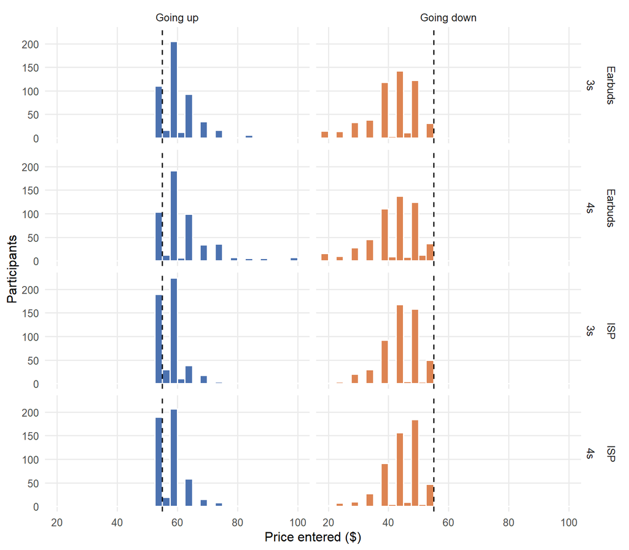

Figure 1: Distribution of prices entered, by product, rating level and direction (primary sample). The x-axis is cut at $20–$100, which covers most answers. The dashed line marks the $55 price of the other option.

```r
ggplot(d, aes(wtp, fill = dir)) +
  geom_histogram(binwidth = 2.5, boundary = 0, colour = "white") +
  geom_vline(xintercept = 55, linetype = "dashed") +
  facet_grid(product + level ~ dir, labeller = labeller(level = c("3s (3.4 vs 3.8)" = "3s", "4s (4.4 vs 4.8)" = "4s"))) +
  coord_cartesian(xlim = c(20, 100)) +
  scale_fill_manual(values = dir_cols, guide = "none") +
  labs(x = "Price entered ($)", y = "Participants")
```

What the raw prices show:

- **Answers concentrate at round numbers.** 87% of all prices are multiples of $5. Going up, the most common answers are $60 and then $55 itself (no premium). Going down, they are $45, $50 and $40.
- **Going up, prices sit just above $55 with a long right tail.** A few participants asked for much more.
- **Going down, prices sit further below $55,** with a tail of large discounts toward $0.
- **99.5% of answers fall between $20 and $100.** The table’s range column shows the few beyond that.

## Mean log premiums

The analyses use the log premium defined above. The table and figure give its mean in each condition, with the equivalent percentage premium.

```r
desc <- d |>
  group_by(dir, level) |>
  summarise(N = n(), `Mean log premium` = mean(log_premium), SD = sd(log_premium),
            .groups = "drop") |>
  mutate(`Premium (%)` = pct(to_pct(`Mean log premium`)),
         across(c(`Mean log premium`, SD), f3))
kbl2(desc, col.names = c("Direction", "Rating level", names(desc)[-(1:2)]))
```

| Direction | Rating level | N | Mean log premium | SD | Premium (%) |
| --- | --- | --- | --- | --- | --- |
| Going up | 3s (3.4 vs 3.8) | 1023 | 0.085 | 0.087 | 8.8% |
| Going up | 4s (4.4 vs 4.8) | 1016 | 0.104 | 0.136 | 11.0% |
| Going down | 3s (3.4 vs 3.8) | 1076 | 0.248 | 0.221 | 28.1% |
| Going down | 4s (4.4 vs 4.8) | 1088 | 0.237 | 0.230 | 26.8% |

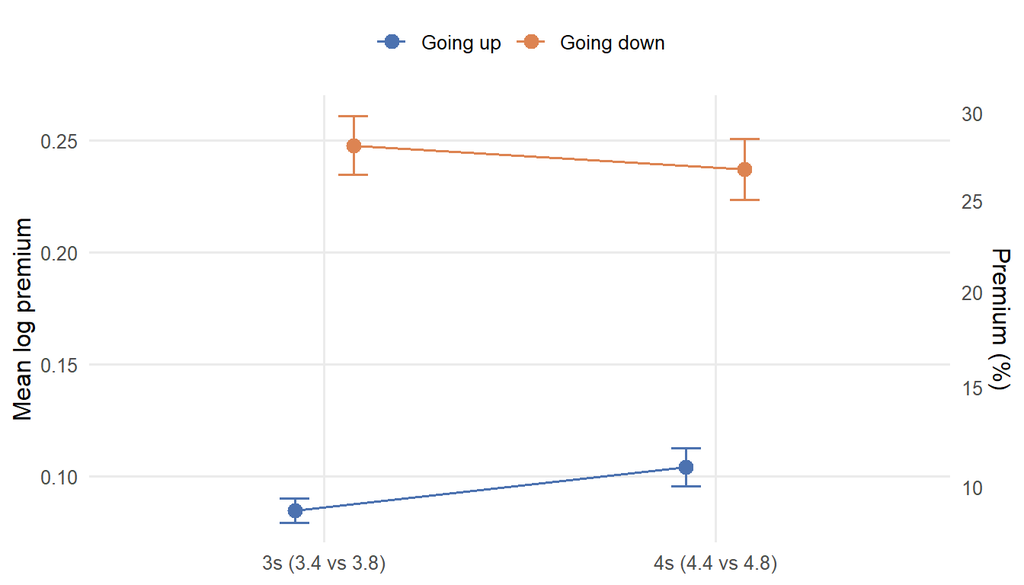

Figure 2: Mean log premium (±95% CI) by rating level and direction. Higher = the better rating is worth more.

```r
cell_ci <- d |>
  group_by(dir, level) |>
  summarise(m = mean(log_premium), se = sd(log_premium) / sqrt(n()), .groups = "drop")
ggplot(cell_ci, aes(level, m, colour = dir, group = dir)) +
  geom_point(size = 3, position = position_dodge(.3)) +
  geom_errorbar(aes(ymin = m - 1.96 * se, ymax = m + 1.96 * se), width = .15,
                position = position_dodge(.3)) +
  geom_line(position = position_dodge(.3)) +
  scale_colour_manual(values = dir_cols, name = NULL) +
  scale_y_continuous(sec.axis = sec_axis(~ 100 * (exp(.) - 1), name = "Premium (%)")) +
  labs(x = NULL, y = "Mean log premium")
```

# Step 1: Does position order matter?

Position order was counterbalanced: in half of each cell the lower-rated option appeared on the left as A, and in the other half on the right as B. This step checks whether order can be ignored.

The check uses **position order** (lower-rated option shown first or second) rather than the label of the option participants priced (A or B). The label flips meaning between directions. Going up, “Target = A” means the higher-rated option was on the left. Going down, it means the lower-rated option was on the left. A main effect of the label would average two opposite position effects, which could cancel out. Position order means the same thing everywhere.

There are two tests, both controlling for rating level, direction and product, with robust (HC3) standard errors:

1. **Main effect:** does showing the lower-rated option first shift premiums overall?
2. **Does order change the other effects?** A single joint test of all interactions between order and rating level and direction. This is what would threaten the main comparisons. Because order is balanced within every cell, a main effect alone would cancel out of every comparison; an interaction would not.

```r
L3 <- "3s (3.4 vs 3.8)"
order_tests <- function(df) {
  df$lowfirst <- as.integer(df$position_order == "lower_first")
  df$tA <- as.integer(df$target_label == "A")
  m0 <- lm(log_premium ~ lowfirst + level * dir * product, data = df)
  m1 <- lm(log_premium ~ lowfirst * level * dir + level * dir * product, data = df)
  m2 <- lm(log_premium ~ lowfirst * level * dir * product, data = df)
  mL <- lm(log_premium ~ tA + level * dir * product, data = df)
  me <- coeftest(m0, vcov = vcovHC(m0, "HC3"))["lowfirst", ]
  ci <- coefci(m0, "lowfirst", vcov = vcovHC(m0, "HC3"))
  lab <- coeftest(mL, vcov = vcovHC(mL, "HC3"))["tA", ]
  w1 <- waldtest(m0, m1, vcov = vcovHC(m1, "HC3"))
  w2 <- waldtest(m0, m2, vcov = vcovHC(m2, "HC3"))
  list(me = me, ci = ci, lab = lab,
       w1 = c(F = w1$F[2], df1 = abs(w1$Df[2]), df2 = w1$Res.Df[2], p = w1$`Pr(>F)`[2]),
       w2 = c(F = w2$F[2], df1 = abs(w2$Df[2]), df2 = w2$Res.Df[2], p = w2$`Pr(>F)`[2]))
}
ot <- order_tests(d)
ot_all <- order_tests(filter(d_all, too_fast == 0))   # wrong-direction answers kept in
fmtF <- function(w) sprintf("F(%d, %d) = %s, %s", w[["df1"]], w[["df2"]], f2(w[["F"]]), p_txt(w[["p"]]))
tibble(
  Test = c("Main effect of position order (lower-rated first − higher-rated first)",
           "Does order change the level or direction effects? (joint test, 3 interaction terms)",
           "Same, also including product (joint test, 7 interaction terms)",
           "For reference: main effect of the A/B label (Target = A − Target = B)"),
  Result = c(sprintf("%s log points [%s, %s], %s", f3(ot$me[1]), f3(ot$ci[1]), f3(ot$ci[2]), p_txt(ot$me[4])),
             fmtF(ot$w1), fmtF(ot$w2),
             sprintf("%s log points, %s", f3(ot$lab[1]), p_txt(ot$lab[4])))
) |> kbl2()
```

| Test | Result |
| --- | --- |
| Main effect of position order (lower-rated first − higher-rated first) | 0.007 log points [-0.004, 0.018], p = .217 |
| Does order change the level or direction effects? (joint test, 3 interaction terms) | F(3, 4191) = 1.14, p = .332 |
| Same, also including product (joint test, 7 interaction terms) | F(7, 4187) = 1.18, p = .313 |
| For reference: main effect of the A/B label (Target = A − Target = B) | 0.002 log points, p = .676 |

```r
order_ok <- ot$me[4] >= .05 && ot$w1[["p"]] >= .05 && ot$w2[["p"]] >= .05
```

**ImportantDecision: collapse across position order**

Position order has no main effect (p = .217) and does not change the rating level or direction effects (p = .332; including product, p = .313). All analyses below collapse across order. Collapsing is also justified by the design: order was balanced within every cell, so each collapsed mean averages over both orders. A non-significant test does not prove order has no effect. The robustness section reruns every comparison within each order separately.

**Wrong-direction answers and order.** With the wrong-direction answers kept in, the order tests give: main effect 0.016 log points (p = .017), interactions p = .068. So an order effect appears only when the wrong-direction answers are included. That fits the idea that some wrong-direction answers came from confusing which option was A and which was B.

# How products are handled

From here on, every comparison runs **separately for earbuds and for ISPs first**. The two products are pooled unless the data show they differ: the **product × comparison interaction** directly tests whether the effect is different for earbuds and ISPs. If it is significant (p < .05), the result is reported by product, and the pooled estimate is shown for reference only.

The rule does not compare the two products’ separate p-values. One product being significant and the other not (say, p < .001 vs. p = .052) does not show that the products differ. The difference between “significant” and “not significant” is not itself statistically significant (Gelman & Stern, 2006). The interaction test asks the right question directly. Each table still reports whether both products reach the same conclusion, for information.

Passing this check is not proof the products are identical. A product difference of about 0.02 log points could go undetected with this sample. The 90% CI of the product difference shows how large a difference the data can rule out.

```r
# Run compare() within each product and pooled; test the product difference with an
# interaction term (ISP difference − earbuds difference); apply the pooling rule.
by_prod <- function(df, var, g1, g2, y = "log_premium") {
  per <- df |> group_by(product) |> group_modify(~ compare(.x, var, g1, g2, y)) |> ungroup() |>
    mutate(Group = as.character(product)) |> select(-product)
  pooled <- compare(df, var, g1, g2, y) |> mutate(Group = "Pooled")
  df$x <- as.integer(df[[var]] == g2); df$isp <- as.integer(df$product == "ISP"); df$yy <- df[[y]]
  m <- lm(yy ~ x * isp, data = df)
  pd <- tibble(pd = unname(coef(m)["x:isp"]),
               pd_lo = confint(m, "x:isp", .95)[1], pd_hi = confint(m, "x:isp", .95)[2],
               pd_lo90 = confint(m, "x:isp", .90)[1], pd_hi90 = confint(m, "x:isp", .90)[2],
               pd_p = summary(m)$coefficients["x:isp", 4])
  e <- filter(per, Group == "Earbuds"); i <- filter(per, Group == "ISP")
  same_concl <- (e$p_t < .05) == (i$p_t < .05) && (e$p_t >= .05 || sign(e$diff) == sign(i$diff))
  pd$same_concl <- same_concl
  pd$pool <- pd$pd_p >= .05
  list(rows = bind_rows(per, pooled), pd = pd)
}
run_strata <- function(df, strat, var, g1, g2, y = "log_premium") {
  lv <- levels(df[[strat]])
  res <- lapply(lv, function(s) by_prod(df[df[[strat]] == s, ], var, g1, g2, y))
  names(res) <- lv
  list(rows = bind_rows(lapply(lv, function(s) mutate(res[[s]]$rows, Stratum = s))),
       pd = bind_rows(lapply(lv, function(s) mutate(res[[s]]$pd, Stratum = s))))
}
tab_rows <- function(r, strat_name, lab1, lab2) {
  r$rows |>
    left_join(select(r$pd, Stratum, pool), by = "Stratum") |>
    mutate(Group = ifelse(Group == "Pooled", ifelse(pool, "Pooled", "Pooled (reference only)"), Group)) |>
    transmute(!!strat_name := Stratum, Product = Group,
              !!paste0("n (", lab1, " / ", lab2, ")") := paste(n1, "/", n2),
              !!paste0(lab1, ": mean (premium)") := sprintf("%s (%s)", f3(m1), pct(to_pct(m1))),
              !!paste0(lab2, ": mean (premium)") := sprintf("%s (%s)", f3(m2), pct(to_pct(m2))),
              !!paste0("Difference: ", lab2, " − ", lab1, " [95% CI]") := sprintf("%s [%s, %s]", f3(diff), f3(lo), f3(hi)),
              `Welch p` = fmt_p(p_t),
              `d [95% CI]` = sprintf("%s [%s, %s]", f2(d), f2(d_lo95), f2(d_hi95))) |>
    kbl2() |>
    collapse_rows(1, valign = "top") |>
    row_spec(which(r$rows$Group == "Pooled"), italic = TRUE)
}
tab_pd <- function(r, strat_name) {
  r$pd |>
    transmute(!!strat_name := Stratum,
              `ISP − earbuds [95% CI]` = sprintf("%s [%s, %s]", f3(pd), f3(pd_lo), f3(pd_hi)),
              `p` = fmt_p(pd_p), `90% CI` = sprintf("[%s, %s]", f3(pd_lo90), f3(pd_hi90)),
              `Same conclusion? (info only)` = ifelse(same_concl, "Yes", "No"),
              Decision = ifelse(pool, "Pool", "Report by product")) |>
    kbl2()
}
get <- function(r, s, g) filter(r$rows, Stratum == s, Group == g)
getpd <- function(r, s) filter(r$pd, Stratum == s)
U <- "Going up"; D <- "Going down"; L4 <- "4s (4.4 vs 4.8)"
desc_line <- function(r, s, lab_hi, lab_lo) {
  x <- getpd(r, s)
  one <- function(g) { z <- get(r, s, g)
    sprintf("%s: %s, %s (%s vs. %s)", g, f3(z$diff), p_txt(z$p_t), pct(to_pct(z$m2)), pct(to_pct(z$m1))) }
  sprintf("%s; %s. Product difference %s (%s). **%s.**", one("Earbuds"), one("ISP"), f3(x$pd), p_txt(x$pd_p),
          if (x$pool) "Pooled" else "Reported by product")
}
```

## Are ISP premiums generally smaller?

Before comparing conditions, it helps to know that the two products differ in their overall premium level. ISP premiums are smaller in every cell:

```r
pl <- d |>
  group_by(dir, level) |>
  group_modify(~ compare(.x, "product", "Earbuds", "ISP")) |>
  ungroup()
pl |>
  transmute(Direction = dir, `Rating level` = level,
            `Earbuds: mean (premium)` = sprintf("%s (%s)", f3(m1), pct(to_pct(m1))),
            `ISP: mean (premium)` = sprintf("%s (%s)", f3(m2), pct(to_pct(m2))),
            `ISP − earbuds [95% CI]` = sprintf("%s [%s, %s]", f3(diff), f3(lo), f3(hi)),
            `Welch p` = fmt_p(p_t)) |>
  kbl2() |> collapse_rows(1, valign = "top")
```

| Direction | Rating level | Earbuds: mean (premium) | ISP: mean (premium) | ISP − earbuds [95% CI] | Welch p |
| --- | --- | --- | --- | --- | --- |
| Going up | 3s (3.4 vs 3.8) | 0.105 (11.1%) | 0.065 (6.7%) | -0.040 [-0.051, -0.030] | < .001 |
|  | 4s (4.4 vs 4.8) | 0.130 (13.8%) | 0.078 (8.1%) | -0.051 [-0.068, -0.035] | < .001 |
| Going down | 3s (3.4 vs 3.8) | 0.285 (33.0%) | 0.210 (23.4%) | -0.075 [-0.101, -0.049] | < .001 |
|  | 4s (4.4 vs 4.8) | 0.271 (31.2%) | 0.203 (22.5%) | -0.068 [-0.095, -0.041] | < .001 |

```r
m_prod_main <- lm(log_premium ~ product + level * dir, data = d)
pm <- coeftest(m_prod_main, vcov = vcovHC(m_prod_main, "HC3"))["productISP", ]
z_share <- d |> filter(direction == "up") |> group_by(product) |> summarise(z = mean(wtp == 55))
rel <- function(g) { a <- get_cell(g, "Going up", "3s (3.4 vs 3.8)"); b <- get_cell(g, "Going up", "4s (4.4 vs 4.8)"); (b - a) / a }
get_cell <- function(g, dr, lv) mean(d$log_premium[d$product == g & d$dir == dr & d$level == lv])
```

Averaged over conditions, the ISP log premium is 0.059 lower than for earbuds (p < .001, controlling for rating level and direction, robust SE). More ISP participants going up would pay nothing extra for the better rating (37% vs. 21% for earbuds).

This matters for reading the product checks below. Because ISP premiums start lower, ISP effects tend to be smaller in absolute terms even when the pattern is the same. For example, going up, the 4s premium exceeds the 3s premium by 23% of the 3s premium for earbuds and 21% for ISPs: proportionally similar.

One caution in comparing levels: the ISP price is monthly, so a smaller monthly premium can still add up to more money over a year than a one-time earbuds premium. The comparison is about how strongly ratings shift the price people state, not about total spending.

# Step 2: Is the premium different in the 3s vs. the 4s?

For each direction, the table gives the mean log premium in the 3s condition (3.4 vs. 3.8) and in the 4s condition (4.4 vs. 4.8), with the percentage premium in parentheses. The **difference is the 4s mean minus the 3s mean**. A positive difference means the same 0.4-star gap is worth more in the 4s. The p-value is from a Welch t-test comparing the two means, and *d* is the difference in standard-deviation units. Results are shown for each product and pooled, collapsed across position order.

```r
r2 <- run_strata(d, "dir", "level", "3s (3.4 vs 3.8)", "4s (4.4 vs 4.8)")
tab_rows(r2, "Direction", "3s", "4s")
```

| Direction | Product | n (3s / 4s) | 3s: mean (premium) | 4s: mean (premium) | Difference: 4s − 3s [95% CI] | Welch p | d [95% CI] |
| --- | --- | --- | --- | --- | --- | --- | --- |
| Going up | Earbuds | 503 / 510 | 0.105 (11.1%) | 0.130 (13.8%) | 0.024 [0.010, 0.038] | < .001 | 0.22 [0.09, 0.34] |
|  | ISP | 520 / 506 | 0.065 (6.7%) | 0.078 (8.1%) | 0.013 [-0.000, 0.027] | .052 | 0.12 [-0.00, 0.24] |
|  | Pooled | 1023 / 1016 | 0.085 (8.8%) | 0.104 (11.0%) | 0.019 [0.009, 0.029] | < .001 | 0.17 [0.08, 0.26] |
| Going down | Earbuds | 541 / 543 | 0.285 (33.0%) | 0.271 (31.2%) | -0.014 [-0.043, 0.015] | .349 | -0.06 [-0.18, 0.06] |
|  | ISP | 535 / 545 | 0.210 (23.4%) | 0.203 (22.5%) | -0.007 [-0.031, 0.016] | .558 | -0.04 [-0.15, 0.08] |
|  | Pooled | 1076 / 1088 | 0.248 (28.1%) | 0.237 (26.8%) | -0.011 [-0.030, 0.008] | .267 | -0.05 [-0.13, 0.04] |

**Product check:**

```r
tab_pd(r2, "Direction")
```

| Direction | ISP − earbuds [95% CI] | p | 90% CI | Same conclusion? (info only) | Decision |
| --- | --- | --- | --- | --- | --- |
| Going up | -0.011 [-0.030, 0.008] | .270 | [-0.027, 0.005] | No | Pool |
| Going down | 0.007 [-0.031, 0.045] | .717 | [-0.025, 0.038] | Yes | Pool |

- **Going up:** Earbuds: 0.024, p < .001 (13.8% vs. 11.1%); ISP: 0.013, p = .052 (8.1% vs. 6.7%). Product difference -0.011 (p = .270). **Pooled.**
- **Going down:** Earbuds: -0.014, p = .349 (31.2% vs. 33.0%); ISP: -0.007, p = .558 (22.5% vs. 23.4%). Product difference 0.007 (p = .717). **Pooled.**

## Does the 3s-vs-4s difference depend on direction?

The table above gives one 3s-vs-4s difference for each direction. Going up, the 4s premium is larger (0.019 log points). Going down, it is not (-0.011). This test asks whether **those two differences are themselves different**: does the extra value of being in the 4s depend on whether people are paying for an upgrade or asking for a discount?

The test statistic is the going-down difference minus the going-up difference: (-0.011) − (0.019) ≈ -0.030. A negative value means the 4s advantage is larger going up. In regression terms, this is the rating level × direction interaction.

```r
int_fit <- function(df, y = "log_premium") {
  df$yy <- df[[y]]
  m <- lm(yy ~ level * dir, data = df)
  k <- "level4s (4.4 vs 4.8):dirGoing down"
  tibble(est = coef(m)[k], lo = confint(m)[k, 1], hi = confint(m)[k, 2], p = summary(m)$coefficients[k, 4])
}
ie <- int_fit(filter(d, product == "Earbuds")); ii <- int_fit(filter(d, product == "ISP"))
m_int <- lm(log_premium ~ level * dir + product, data = d)
k <- "level4s (4.4 vs 4.8):dirGoing down"
co_int <- summary(m_int)$coefficients[k, ]; ci_int <- confint(m_int)[k, ]
m3 <- lm(log_premium ~ level * dir * product, data = d)
k3 <- "level4s (4.4 vs 4.8):dirGoing down:productISP"
p3 <- summary(m3)$coefficients[k3, ]; ci3 <- confint(m3)[k3, ]; ci3_90 <- confint(m3, level = .90)[k3, ]
int_same <- ((ie$p < .05) == (ii$p < .05)) && (ie$p >= .05 || sign(ie$est) == sign(ii$est))
int_pool <- p3[4] >= .05
sd_res <- sd(d$log_premium)
gp2 <- function(g, s) f3(get(r2, s, g)$diff)
tibble(Product = c("Earbuds", "ISP", ifelse(int_pool, "Pooled (controls for product)", "Pooled (reference only)")),
       `4s − 3s, going up` = c(gp2("Earbuds", U), gp2("ISP", U), gp2("Pooled", U)),
       `4s − 3s, going down` = c(gp2("Earbuds", D), gp2("ISP", D), gp2("Pooled", D)),
       `Down − up [95% CI]` = c(sprintf("%s [%s, %s]", f3(ie$est), f3(ie$lo), f3(ie$hi)),
                                sprintf("%s [%s, %s]", f3(ii$est), f3(ii$lo), f3(ii$hi)),
                                sprintf("%s [%s, %s]", f3(co_int[1]), f3(ci_int[1]), f3(ci_int[2]))),
       p = fmt_p(c(ie$p, ii$p, co_int[4]))) |>
  kbl2() |> row_spec(3, italic = TRUE)
```

| Product | 4s − 3s, going up | 4s − 3s, going down | Down − up [95% CI] | p |
| --- | --- | --- | --- | --- |
| Earbuds | 0.024 | -0.014 | -0.038 [-0.071, -0.005] | .023 |
| ISP | 0.013 | -0.007 | -0.021 [-0.048, 0.007] | .144 |
| Pooled (controls for product) | 0.019 | -0.011 | -0.029 [-0.051, -0.008] | .008 |

**Result:** yes, a significant rating level × direction interaction (b = -0.029, p = .008, pooled across products). The 3s-vs-4s difference depends on direction: the 0.4-star gap is worth more in the 4s when people pay for an upgrade, but not when they ask for a discount to accept a downgrade.

**By product:** the estimate is -0.038 for earbuds (p = .023) and -0.021 for ISPs (p = .144). Both point the same way. The ISP estimate is smaller, in line with ISPs’ generally smaller premiums (see above). The two products do not differ significantly (0.018 log points, 95% CI [-0.025, 0.061], p = .416), so the result is **pooled**. One product reaching p < .05 and the other not does not mean they differ.

# Step 3: Is the premium different going up vs. going down?

For each rating level, the table gives the mean log premium going up and going down, with the percentage premium in parentheses. The **difference is the going-down mean minus the going-up mean**. A positive difference means the premium is larger when participants price the lower-rated option (how much cheaper it must be) than when they price the higher-rated option (how much more it is worth). The p-value is from a Welch t-test. Results are shown for each product and pooled, collapsed across position order.

```r
r3 <- run_strata(d, "level", "dir", "Going up", "Going down")
tab_rows(r3, "Rating level", "Up", "Down")
```

| Rating level | Product | n (Up / Down) | Up: mean (premium) | Down: mean (premium) | Difference: Down − Up [95% CI] | Welch p | d [95% CI] |
| --- | --- | --- | --- | --- | --- | --- | --- |
| 3s (3.4 vs 3.8) | Earbuds | 503 / 541 | 0.105 (11.1%) | 0.285 (33.0%) | 0.180 [0.157, 0.203] | < .001 | 0.92 [0.79, 1.05] |
|  | ISP | 520 / 535 | 0.065 (6.7%) | 0.210 (23.4%) | 0.145 [0.129, 0.161] | < .001 | 1.10 [0.97, 1.23] |
|  | Pooled (reference only) | 1023 / 1076 | 0.085 (8.8%) | 0.248 (28.1%) | 0.163 [0.149, 0.177] | < .001 | 0.96 [0.87, 1.05] |
| 4s (4.4 vs 4.8) | Earbuds | 510 / 543 | 0.130 (13.8%) | 0.271 (31.2%) | 0.142 [0.119, 0.164] | < .001 | 0.74 [0.62, 0.87] |
|  | ISP | 506 / 545 | 0.078 (8.1%) | 0.203 (22.5%) | 0.125 [0.103, 0.147] | < .001 | 0.67 [0.55, 0.80] |
|  | Pooled | 1016 / 1088 | 0.104 (11.0%) | 0.237 (26.8%) | 0.133 [0.117, 0.149] | < .001 | 0.70 [0.61, 0.79] |

**Product check:**

```r
tab_pd(r3, "Rating level")
```

| Rating level | ISP − earbuds [95% CI] | p | 90% CI | Same conclusion? (info only) | Decision |
| --- | --- | --- | --- | --- | --- |
| 3s (3.4 vs 3.8) | -0.035 [-0.063, -0.006] | .017 | [-0.059, -0.011] | Yes | Report by product |
| 4s (4.4 vs 4.8) | -0.017 [-0.049, 0.015] | .302 | [-0.044, 0.010] | Yes | Pool |

- **3s:** Earbuds: 0.180, p < .001 (33.0% vs. 11.1%); ISP: 0.145, p < .001 (23.4% vs. 6.7%). Product difference -0.035 (p = .017). **Reported by product.**
- **4s:** Earbuds: 0.142, p < .001 (31.2% vs. 13.8%); ISP: 0.125, p < .001 (22.5% vs. 8.1%). Product difference -0.017 (p = .302). **Pooled.**

# Zero premiums: who values the gap at all, and by how much?

Many participants entered exactly $55, meaning they would pay nothing extra for the better rating (going up) or need no discount to take the worse one (going down). These are kept: a zero is a valid answer, and nothing about how these participants responded suggests they failed the task. Excluding them would also remove far more people going up than going down, so the two groups would no longer be comparable.

Instead, the premium is split into two parts:

1. **Does the participant value the rating gap at all?** The share with a premium above zero.
2. **If so, how much?** The mean premium among those participants only.

Collapsed across position order and product.

```r
d <- d |> mutate(pos = as.integer(log_premium > 0))
part1 <- d |> group_by(dir, level) |>
  summarise(n = n(), k = sum(pos), share = mean(pos), .groups = "drop")
pt <- function(df, var, g1, g2) {
  a <- df[df[[var]] == g1, ]; b <- df[df[[var]] == g2, ]
  t <- prop.test(c(sum(b$pos), sum(a$pos)), c(nrow(b), nrow(a)))
  tibble(s1 = mean(a$pos), s2 = mean(b$pos), diff = mean(b$pos) - mean(a$pos),
         lo = t$conf.int[1], hi = t$conf.int[2], p = t$p.value)
}
pos_d <- filter(d, pos == 1)
p1_ud <- d |> group_by(level) |> group_modify(~ pt(.x, "dir", "Going up", "Going down")) |> ungroup()
p1_lv <- d |> group_by(dir) |> group_modify(~ pt(.x, "level", "3s (3.4 vs 3.8)", "4s (4.4 vs 4.8)")) |> ungroup()
p2_ud <- pos_d |> group_by(level) |> group_modify(~ compare(.x, "dir", "Going up", "Going down")) |> ungroup()
p2_lv <- pos_d |> group_by(dir) |> group_modify(~ compare(.x, "level", "3s (3.4 vs 3.8)", "4s (4.4 vs 4.8)")) |> ungroup()
part2 <- pos_d |> group_by(dir, level) |>
  summarise(n = n(), m = mean(log_premium), dol = mean(dollar_premium), .groups = "drop")
```

**Part 1: share with any premium**

```r
part1 |>
  transmute(Direction = dir, `Rating level` = level, `n` = n,
            `Premium above zero` = sprintf("%d (%s)", k, pct(share)),
            `Zero premium` = sprintf("%d (%s)", n - k, pct(1 - share))) |>
  kbl2()
```

| Direction | Rating level | n | Premium above zero | Zero premium |
| --- | --- | --- | --- | --- |
| Going up | 3s (3.4 vs 3.8) | 1023 | 724 (70.8%) | 299 (29.2%) |
| Going up | 4s (4.4 vs 4.8) | 1016 | 724 (71.3%) | 292 (28.7%) |
| Going down | 3s (3.4 vs 3.8) | 1076 | 1008 (93.7%) | 68 (6.3%) |
| Going down | 4s (4.4 vs 4.8) | 1088 | 1021 (93.8%) | 67 (6.2%) |

**Part 2: premium among participants who value the gap**

```r
part2 |>
  transmute(Direction = dir, `Rating level` = level, n,
            `Mean log premium (premium %)` = sprintf("%s (%s)", f3(m), pct(to_pct(m))),
            `Mean dollar premium` = sprintf("$%.2f", dol)) |>
  kbl2()
```

| Direction | Rating level | n | Mean log premium (premium %) | Mean dollar premium |
| --- | --- | --- | --- | --- |
| Going up | 3s (3.4 vs 3.8) | 724 | 0.120 (12.7%) | $7.33 |
| Going up | 4s (4.4 vs 4.8) | 724 | 0.146 (15.7%) | $9.79 |
| Going down | 3s (3.4 vs 3.8) | 1008 | 0.265 (30.3%) | $12.17 |
| Going down | 4s (4.4 vs 4.8) | 1021 | 0.253 (28.7%) | $11.66 |

**Tests**

```r
s_row <- function(lab, x) sprintf("%s → %s; difference %s points [%s, %s], %s",
                                  pct(x$s1), pct(x$s2), sprintf("%+.1f", 100 * x$diff),
                                  sprintf("%.1f", 100 * min(x$lo, x$hi)), sprintf("%.1f", 100 * max(x$lo, x$hi)), p_txt(x$p))
m_row <- function(x) sprintf("%s → %s; difference %s [%s, %s], %s",
                             f3(x$m1), f3(x$m2), f3(x$diff), f3(x$lo), f3(x$hi), p_txt(x$p_t))
tibble(
  Comparison = c("Up → down, 3s", "Up → down, 4s", "3s → 4s, going up", "3s → 4s, going down"),
  `Part 1: share with any premium (two-proportion test)` =
    c(s_row(NA, p1_ud[1, ]), s_row(NA, p1_ud[2, ]), s_row(NA, p1_lv[1, ]), s_row(NA, p1_lv[2, ])),
  `Part 2: mean log premium among them (Welch)` =
    c(m_row(p2_ud[1, ]), m_row(p2_ud[2, ]), m_row(p2_lv[1, ]), m_row(p2_lv[2, ]))
) |> kbl2()
```

| Comparison | Part 1: share with any premium (two-proportion test) | Part 2: mean log premium among them (Welch) |
| --- | --- | --- |
| Up → down, 3s | 70.8% → 93.7%; difference +22.9 points [19.7, 26.1], p < .001 | 0.120 → 0.265; difference 0.145 [0.130, 0.160], p < .001 |
| Up → down, 4s | 71.3% → 93.8%; difference +22.6 points [19.4, 25.8], p < .001 | 0.146 → 0.253; difference 0.107 [0.089, 0.124], p < .001 |
| 3s → 4s, going up | 70.8% → 71.3%; difference +0.5 points [-3.5, 4.5], p = .846 | 0.120 → 0.146; difference 0.026 [0.015, 0.038], p < .001 |
| 3s → 4s, going down | 93.7% → 93.8%; difference +0.2 points [-2.0, 2.3], p = .947 | 0.265 → 0.253; difference -0.012 [-0.031, 0.008], p = .230 |

```r
r_ud3 <- to_pct(p2_ud$m2[1]) / to_pct(p2_ud$m1[1]); r_ud4 <- to_pct(p2_ud$m2[2]) / to_pct(p2_ud$m1[2])
```

**NoteShare with any premium, by product**

```r
p1_prod |> mutate(share = pct(share)) |>
  pivot_wider(names_from = level, values_from = share) |>
  rename(Product = product, Direction = dir) |> kbl2()
```

| Product | Direction | 3s (3.4 vs 3.8) | 4s (4.4 vs 4.8) |
| --- | --- | --- | --- |
| Earbuds | Going up | 78.1% | 79.8% |
| Earbuds | Going down | 95.4% | 93.9% |
| ISP | Going up | 63.7% | 62.6% |
| ISP | Going down | 92.0% | 93.8% |

**What this shows**

- **Loss aversion holds on both parts.** Far more people want compensation to take the worse-rated option (93.7%–93.8%) than will pay anything extra for the better-rated one (70.8%–71.3%). Among people who value the gap at all, the going-down premium is still 1.8–2.4 times the going-up premium (in dollars, about $11.66–$12.17 vs. $7.33–$9.79).
- **Part 2 is a conservative test of the asymmetry.** Looking only at people above zero removes many more low-valuing people going up (about 29.0%) than going down (about 6.2%). That raises the going-up mean relative to the going-down mean, which works *against* the asymmetry. Going down still shows the larger premium.
- **The 4s advantage going up comes from the size of the premium, not from more people caring.** The share with any premium is about the same in the 3s and 4s (70.8% vs. 71.3%, p = .846). Among those who value the gap, the 4s premium is larger (0.026 log points, p < .001). Near the top of the scale, consumers who value a rating difference pay more for it. The share who value it at all is unchanged.
- **Going down, neither part differs** between the 3s and 4s (share p = .947; premium p = .230).

# Exploratory: does review-reading frequency moderate the 3s-vs-4s effect?

This section is **exploratory**: it was not planned before the data were seen. It asks whether the pricing results track an earlier finding about *perception*.

**Background.** The mixed-design study (`mixed_design_10.29.26_flagged.csv`, after that report’s exclusions) asked how large rating differences *feel* on a 0–100 slider. It included the exact pairs used here (3.4 vs. 3.8 and 4.4 vs. 4.8). There, the 4s gap felt larger than the 3s gap, and more so for people who read reviews more often. If the price people put on a gap follows how big it feels, the pricing data should show the same pattern going up. The sections above suggest perceived size does not turn into money going down.

```r
# Perception: the mixed-design study, with that report's exclusions (bot flags and zero-check failures)
md <- read_csv("mixed_design_10.29.26_flagged.csv", show_col_types = FALSE) |>
  mutate(fail_zero = as.integer(a0.0 >= 10 | probe_rating >= 10)) |>
  filter(bot_any == 0, fail_zero == 0)
rf_lab <- function(x) cut(x, c(0, 3, 4, 5), labels = c("Sometimes or less", "Often", "Always / very often"))
perc <- md |> mutate(grp = rf_lab(review_freq)) |>
  group_by(grp) |> summarise(n = n(), p3 = mean(d3.4), p4 = mean(d4.4), .groups = "drop") |>
  bind_rows(md |> summarise(grp = factor("All"), n = n(), p3 = mean(d3.4), p4 = mean(d4.4)))
# Pricing: this study
d <- d |> mutate(rf = rf_lab(review_freq))
rf_cells <- d |>
  group_by(dir, rf) |>
  group_modify(~ compare(.x, "level", "3s (3.4 vs 3.8)", "4s (4.4 vs 4.8)")) |>
  ungroup()
```

**Perception vs. pricing, by how often people read reviews.** Each “4s vs. 3s” column shows how much larger the 4s gap is than the 3s gap, as a percentage. For perception it is the ratio of mean slider ratings. For pricing it is the ratio of percentage premiums. Each p-value is a Welch t-test of the 4s vs. 3s mean log premium *within that direction and review-frequency group of this study*. No test compares pricing with perception: the two come from different studies on different scales. Going-down answers vary about twice as much as going-up answers, so a going-down difference of the same size has a larger p-value.

```r
pr <- rf_cells |>
  transmute(dir, grp = as.character(rf), n = n1 + n2,
            ratio = to_pct(m2) / to_pct(m1) - 1,
            cell = sprintf("%s → %s (%s), %s", pct(to_pct(m1)), pct(to_pct(m2)),
                           sprintf("%+.3f", diff), sapply(p_t, p_txt)))
pc <- perc |> filter(grp != "All") |> transmute(grp = as.character(grp), n_perc = n, perc_ratio = p4 / p3 - 1)
up <- filter(pr, dir == "Going up"); dn <- filter(pr, dir == "Going down")
tibble(`Reads reviews` = up$grp,
       `Perception: n` = pc$n_perc, `Perception: 4s vs. 3s` = sprintf("%+.0f%%", 100 * pc$perc_ratio),
       `Going up: n` = up$n, `Going up: 3s → 4s premium (diff), p` = up$cell,
       `Going up: 4s vs. 3s` = sprintf("%+.0f%%", 100 * up$ratio),
       `Going down: n` = dn$n, `Going down: 3s → 4s premium (diff), p` = dn$cell,
       `Going down: 4s vs. 3s` = sprintf("%+.0f%%", 100 * dn$ratio)) |>
  kbl2()
```

| Reads reviews | Perception: n | Perception: 4s vs. 3s | Going up: n | Going up: 3s → 4s premium (diff), p | Going up: 4s vs. 3s | Going down: n | Going down: 3s → 4s premium (diff), p | Going down: 4s vs. 3s |
| --- | --- | --- | --- | --- | --- | --- | --- | --- |
| Sometimes or less | 110 | +10% | 281 | 7.4% → 7.5% (+0.001), p = .917 | +1% | 263 | 20.6% → 21.6% (+0.008), p = .767 | +5% |
| Often | 232 | +22% | 977 | 8.9% → 11.5% (+0.024), p = .003 | +29% | 1019 | 26.9% → 24.1% (-0.023), p = .051 | -10% |
| Always / very often | 162 | +33% | 781 | 9.3% → 11.5% (+0.021), p = .008 | +25% | 882 | 31.7% → 31.8% (+0.001), p = .966 | +0% |

**What it shows**

- **Going up, the pattern matches perception.** The 4s advantage is essentially zero among people who read reviews sometimes or less (+1%). It is about 25–29% among people who read them often or always. In perception, the same groups gave +10%, +22% and +33%. Pricing looks more like a step than a steady increase.
- **Going down, there is no pattern.** The 4s and 3s discounts are about equal in every group, so how big the gap feels does not show up in the discount people require.
- **The formal tests are not significant.** The linear trend going up (does the 4s advantage grow with each step of review frequency?) is b = 0.008 (p = .176). Going down it is b = 0.003 (p = .815). The difference between directions has p = .775. The low-frequency group is small (281 going up), so its estimate is imprecise.
- **A clearer finding: frequent review readers demand larger premiums overall, especially going down.** Going down, the premium rises from about 21.2% to 31.7% across groups (b = 0.039 per step, p < .001). Going up, it rises from 7.4% to 10.4% (b = 0.008 per step, p = .004). People who rely on reviews most react most strongly to *losing* rating quality.

**Caveats**

- The perception and pricing results come from different people and different tasks. The comparison of the two “4s vs. 3s” columns is suggestive, not a direct test.
- The top answer on the review-frequency question differed between studies: “Very often” in the mixed-design study vs. “Always” here.
- Review frequency was measured, not manipulated, and almost everyone on Prolific reads reviews often or always.
- A stronger test would manipulate exposure to rating distributions (as in the range-frequency preregistration), or measure perceived size and price in the same people.

# Raw prices: distribution and robustness

The analyses above use the log premium. This section asks two things. First, does the price distribution justify logging? Second, do the conclusions change if the premium is measured in raw dollars, `dollar_premium` = p_high − p_low (going up: WTP − $55; going down: $55 − WTP)?

## Does the distribution warrant logging?

Normal-looking individual answers are not required here. With about 500 or more people per group, the means being compared are close to normally distributed anyway. What logging can buy is (1) less skew and fewer extreme values pulling the means around, and (2) a scale where a premium means the same thing in both directions. Both are checked below.

```r
skew <- function(x) { z <- x - mean(x); mean(z^3) / mean(z^2)^1.5 }
kurt <- function(x) { z <- x - mean(x); mean(z^4) / mean(z^2)^2 - 3 }
out3 <- function(x) mean(abs(x - mean(x)) > 3 * sd(x))
shape <- d |>
  group_by(Product = product, Direction = dir, `Rating level` = level) |>
  summarise(n = n(),
            `$ mean (SD)` = sprintf("%.2f (%.2f)", mean(dollar_premium), sd(dollar_premium)),
            `$ median` = sprintf("%.2f", median(dollar_premium)),
            `$ skew` = skew(dollar_premium), `log skew` = skew(log_premium),
            `$ excess kurtosis` = kurt(dollar_premium), `log excess kurtosis` = kurt(log_premium),
            `$ beyond 3 SD` = out3(dollar_premium), `log beyond 3 SD` = out3(log_premium),
            `% zero premium` = mean(dollar_premium == 0), .groups = "drop")
shape |>
  mutate(across(c(`$ skew`, `log skew`, `$ excess kurtosis`, `log excess kurtosis`), f2),
         across(c(`$ beyond 3 SD`, `log beyond 3 SD`, `% zero premium`), ~ pct(.x))) |>
  kbl2() |> collapse_rows(1:2, valign = "top")
```

| Product | Direction | Rating level | n | $ mean (SD) | $ median | $ skew | log skew | $ excess kurtosis | log excess kurtosis | $ beyond 3 SD | log beyond 3 SD | % zero premium |
| --- | --- | --- | --- | --- | --- | --- | --- | --- | --- | --- | --- | --- |
| Earbuds | Going up | 3s (3.4 vs 3.8) | 503 | 6.52 (6.52) | 5.00 | 2.07 | 1.54 | 6.62 | 3.65 | 2.2% | 2.2% | 21.9% |
|  |  | 4s (4.4 vs 4.8) | 510 | 8.31 (9.34) | 5.00 | 2.54 | 1.83 | 8.97 | 4.58 | 2.2% | 2.2% | 20.2% |
|  | Going down | 3s (3.4 vs 3.8) | 541 | 12.77 (8.52) | 10.00 | 1.22 | 2.72 | 1.91 | 11.70 | 1.1% | 1.3% | 4.6% |
|  |  | 4s (4.4 vs 4.8) | 543 | 12.29 (8.29) | 10.00 | 1.12 | 2.47 | 1.50 | 10.93 | 0.7% | 3.7% | 6.1% |
| ISP | Going up | 3s (3.4 vs 3.8) | 520 | 3.90 (4.62) | 5.00 | 2.68 | 1.93 | 14.67 | 7.39 | 1.3% | 1.3% | 36.3% |
|  |  | 4s (4.4 vs 4.8) | 506 | 5.62 (23.72) | 5.00 | 18.91 | 9.76 | 388.96 | 139.37 | 0.4% | 0.6% | 37.4% |
|  | Going down | 3s (3.4 vs 3.8) | 535 | 10.02 (6.66) | 10.00 | 1.18 | 2.65 | 2.78 | 13.76 | 0.7% | 1.5% | 8.0% |
|  |  | 4s (4.4 vs 4.8) | 545 | 9.59 (6.37) | 10.00 | 1.54 | 10.19 | 5.65 | 167.55 | 1.8% | 0.6% | 6.2% |

Skew of 0 and excess kurtosis of 0 match a normal distribution. Skew beyond about ±1 or excess kurtosis above about 3 means a long tail or heavy outliers.

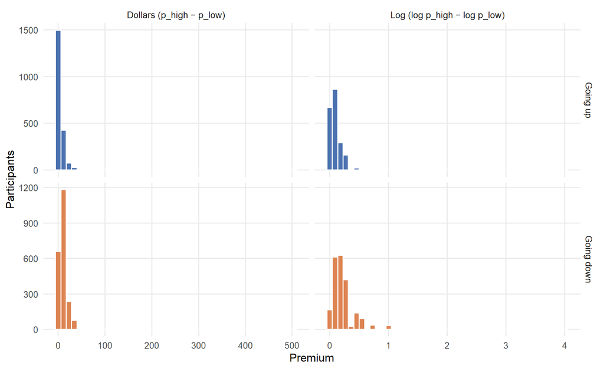

Figure 3: Distribution of the premium in dollars (left) and logs (right), by direction (primary sample, both products and rating levels). The spike at 0 is people who entered exactly $55.

```r
d |>
  select(dir, `Dollars (p_high − p_low)` = dollar_premium, `Log (log p_high − log p_low)` = log_premium) |>
  pivot_longer(-dir, names_to = "Scale", values_to = "v") |>
  ggplot(aes(v, fill = dir)) +
  geom_histogram(bins = 45, colour = "white") +
  facet_grid(dir ~ Scale, scales = "free") +
  scale_fill_manual(values = dir_cols, guide = "none") +
  labs(x = "Premium", y = "Participants")
```

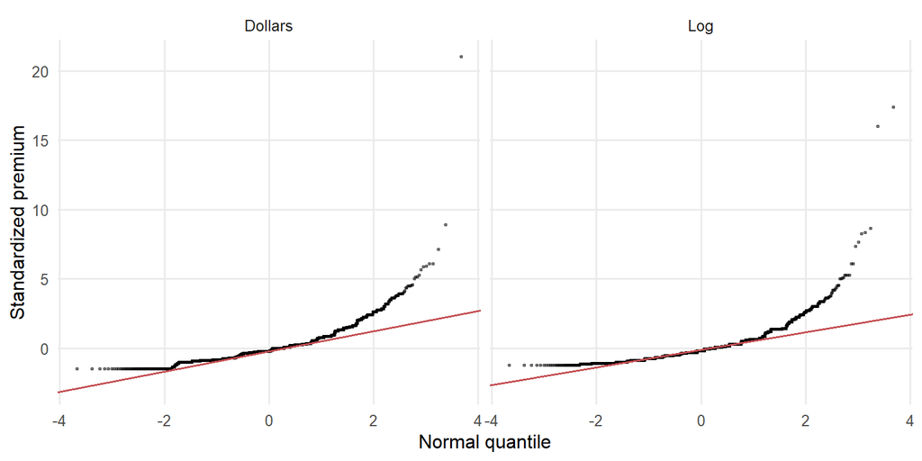

Figure 4: Normal Q-Q plots of within-cell standardized premiums (each value minus its product × direction × level cell mean, divided by the cell SD). Points on the line = normal; points curving away at the ends = long tails.

```r
d |>
  group_by(product, dir, level) |>
  mutate(Dollars = (dollar_premium - mean(dollar_premium)) / sd(dollar_premium),
         Log = (log_premium - mean(log_premium)) / sd(log_premium)) |>
  ungroup() |>
  select(Dollars, Log) |>
  pivot_longer(everything(), names_to = "Scale", values_to = "z") |>
  ggplot(aes(sample = z)) +
  stat_qq(size = .6, alpha = .4) + stat_qq_line(colour = "#C44E52") +
  facet_wrap(~ Scale) +
  labs(x = "Normal quantile", y = "Standardized premium")
```

**Shape:** across the 8 cells, median |skew| is 1.80 in dollars vs. 2.56 in logs, and median excess kurtosis is 6.13 vs. 11.32 (largest cell: 388.96 vs. 167.55).

**Logging does not make the premium more normal overall.** It depends on direction:

- **Going up,** logging helps. The long right tail (a few people asking much more for the better option) is pulled in: median skew 2.61 → 1.88, excess kurtosis 11.82 → 5.99. The ISP going-up 4s cell has extreme kurtosis on both scales because of one $560 answer (a $505 premium).
- **Going down,** logging hurts. Small prices (e.g., $10 for the lower-rated option) become very large log premiums (log(56/11) = 1.63), creating a new tail: median skew 1.20 → 2.69, excess kurtosis 2.34 → 12.73.
- **Neither scale is close to normal.** The distributions are lumpy: 29.0% of going-up participants gave exactly $0 premium, and most answers are round numbers ($5, $10, …).

**Why the two directions behave differently.** The log squeezes big numbers together and spreads small numbers apart. A $10 change near $55 is a small log change, but a $10 change near $5 is a huge one. Which tail the log affects depends on where the extreme answers sit:

- **Going up,** the price entered is *above* $55, and the extreme answers are large ($100, $150, $560). The log squeezes them, so the long right tail shrinks.
- **Going down,** the price entered is *below* $55, and the extreme answers are small ($20, $10, $5, $0). The log spreads them, so a new tail appears. In dollars, cutting from $45 to $35 and from $15 to $5 are both $10. In logs (with the +1), they are 0.25 and 0.98.
- Put another way, the dollar premium going down cannot exceed $55, because nobody can enter a price below $0, so its tail is naturally capped. The log removes that cap: as the price approaches $0, the log premium grows without limit.

**So logging is not justified as a fix for non-normality.** The case for logs is the scale argument below. Because neither scale is well-behaved, the rank tests (see Robustness) are the main safeguard against outliers.

## Do the conclusions hold in dollars?

```r
r2d <- run_strata(d, "dir", "level", "3s (3.4 vs 3.8)", "4s (4.4 vs 4.8)", y = "dollar_premium")
r3d <- run_strata(d, "level", "dir", "Going up", "Going down", y = "dollar_premium")
ied <- int_fit(filter(d, product == "Earbuds"), "dollar_premium")
iid <- int_fit(filter(d, product == "ISP"), "dollar_premium")
m3d <- lm(dollar_premium ~ level * dir * product, data = d)
p3d <- summary(m3d)$coefficients[k3, ]
md <- lm(dollar_premium ~ level * dir + product, data = d)
co_intd <- summary(md)$coefficients[k, ]
int_same_d <- ((ied$p < .05) == (iid$p < .05)) && (ied$p >= .05 || sign(ied$est) == sign(iid$est))
int_pool_d <- p3d[4] >= .05

fmt_d <- function(x, p) sprintf("%s (%s)", sprintf("%.2f", x), p_txt(p))
fmt_l <- function(x, p) sprintf("%s (%s)", f3(x), p_txt(p))
agree <- function(x1, p1, x2, p2) ((p1 < .05) == (p2 < .05)) && (p1 >= .05 || sign(x1) == sign(x2))
cmp_row <- function(lab, rl, rd, s) {
  out <- lapply(c("Earbuds", "ISP"), function(g) {
    a <- get(rl, s, g); b <- get(rd, s, g)
    c(log = fmt_l(a$diff, a$p_t), dol = fmt_d(b$diff, b$p_t), ok = agree(a$diff, a$p_t, b$diff, b$p_t))
  })
  tibble(Comparison = lab,
         `Earbuds: log` = out[[1]]["log"], `Earbuds: $` = out[[1]]["dol"],
         `ISP: log` = out[[2]]["log"], `ISP: $` = out[[2]]["dol"],
         `Pooling decision (log / $)` = paste(ifelse(getpd(rl, s)$pool, "Pool", "By product"), "/",
                                             ifelse(getpd(rd, s)$pool, "Pool", "By product")),
         `Same conclusion?` = ifelse(out[[1]]["ok"] == "TRUE" && out[[2]]["ok"] == "TRUE" &&
                                       getpd(rl, s)$pool == getpd(rd, s)$pool, "Yes", "No"))
}
dol_tab <- bind_rows(
  cmp_row("4s − 3s, going up", r2, r2d, U),
  cmp_row("4s − 3s, going down", r2, r2d, D),
  cmp_row("Down − up, 3s", r3, r3d, L3),
  cmp_row("Down − up, 4s", r3, r3d, L4),
  tibble(Comparison = "4s − 3s difference: down − up",
         `Earbuds: log` = fmt_l(ie$est, ie$p), `Earbuds: $` = fmt_d(ied$est, ied$p),
         `ISP: log` = fmt_l(ii$est, ii$p), `ISP: $` = fmt_d(iid$est, iid$p),
         `Pooling decision (log / $)` = paste(ifelse(int_pool, "Pool", "By product"), "/",
                                             ifelse(int_pool_d, "Pool", "By product")),
         `Same conclusion?` = ifelse(agree(ie$est, ie$p, ied$est, ied$p) && agree(ii$est, ii$p, iid$est, iid$p) &&
                                       int_pool == int_pool_d, "Yes", "No"))
)
kbl2(dol_tab)
```

| Comparison | Earbuds: log | Earbuds: $ | ISP: log | ISP: $ | Pooling decision (log / $) | Same conclusion? |
| --- | --- | --- | --- | --- | --- | --- |
| 4s − 3s, going up | 0.024 (p < .001) | 1.80 (p < .001) | 0.013 (p = .052) | 1.72 (p = .110) | Pool / Pool | Yes |
| 4s − 3s, going down | -0.014 (p = .349) | -0.47 (p = .356) | -0.007 (p = .558) | -0.42 (p = .286) | Pool / Pool | Yes |
| Down − up, 3s | 0.180 (p < .001) | 6.25 (p < .001) | 0.145 (p < .001) | 6.11 (p < .001) | By product / Pool | No |
| Down − up, 4s | 0.142 (p < .001) | 3.98 (p < .001) | 0.125 (p < .001) | 3.97 (p < .001) | Pool / Pool | Yes |
| 4s − 3s difference: down − up | -0.038 (p = .023) | -2.27 (p = .002) | -0.021 (p = .144) | -2.14 (p = .054) | Pool / Pool | Yes |

“Same conclusion” means that for both products the effect is significant in the same direction on both scales (or not significant on either), and the pooling decision matches.

**4 of 5 conclusions are the same in dollars.** Every significant effect stays significant in the same direction, and every non-significant one stays non-significant.

The one difference is a pooling decision, not an effect. For up vs. down in the 3s, the products differ in logs (p = .017) but not in dollars (p = .817). Earbuds and ISPs have similar dollar gaps. But earbuds have larger going-down dollar premiums, and the log scale stretches large going-down premiums the most (the $10 example above), so logs widen the earbuds gap more. Either way, going down beats going up for both products.

In dollars, the going-down premium is about twice the going-up premium: $11.40 vs. $5.19 in the 3s, and $10.94 vs. $6.97 in the 4s (pooled, for scale). So the large up-vs-down difference is not created by the log scale. Logs make it a little larger, as the $10 example above shows.

**NoteFull dollar results (by product, with product checks)**

```r
tab_rows_d <- function(r, strat_name, diff_name) {
  r$rows |>
    left_join(select(r$pd, Stratum, pool), by = "Stratum") |>
    mutate(Group = ifelse(Group == "Pooled", ifelse(pool, "Pooled", "Pooled (reference only)"), Group)) |>
    transmute(!!strat_name := Stratum, Product = Group, n = paste(n1, "/", n2),
              `Mean $` = sprintf("%.2f → %.2f", m1, m2),
              !!diff_name := sprintf("%.2f [%.2f, %.2f]", diff, lo, hi),
              `Welch p` = fmt_p(p_t), d = f2(d)) |>
    kbl2() |> collapse_rows(1, valign = "top")
}
tab_rows_d(r2d, "Direction", "4s − 3s, $ [95% CI]")
```

| Direction | Product | n | Mean $ | 4s − 3s, $ [95% CI] | Welch p | d |
| --- | --- | --- | --- | --- | --- | --- |
| Going up | Earbuds | 503 / 510 | 6.52 → 8.31 | 1.80 [0.80, 2.79] | < .001 | 0.22 |
|  | ISP | 520 / 506 | 3.90 → 5.62 | 1.72 [-0.39, 3.83] | .110 | 0.10 |
|  | Pooled | 1023 / 1016 | 5.19 → 6.97 | 1.79 [0.62, 2.95] | .003 | 0.13 |
| Going down | Earbuds | 541 / 543 | 12.77 → 12.29 | -0.47 [-1.47, 0.53] | .356 | -0.06 |
|  | ISP | 535 / 545 | 10.02 → 9.59 | -0.42 [-1.20, 0.36] | .286 | -0.07 |
|  | Pooled | 1076 / 1088 | 11.40 → 10.94 | -0.46 [-1.10, 0.19] | .164 | -0.06 |

```r
tab_pd(r2d, "Direction")
```

| Direction | ISP − earbuds [95% CI] | p | 90% CI | Same conclusion? (info only) | Decision |
| --- | --- | --- | --- | --- | --- |
| Going up | -0.077 [-2.391, 2.237] | .948 | [-2.019, 1.865] | No | Pool |
| Going down | 0.047 [-1.221, 1.316] | .942 | [-1.017, 1.112] | Yes | Pool |

```r
tab_rows_d(r3d, "Rating level", "Down − Up, $ [95% CI]")
```

| Rating level | Product | n | Mean $ | Down − Up, $ [95% CI] | Welch p | d |
| --- | --- | --- | --- | --- | --- | --- |
| 3s (3.4 vs 3.8) | Earbuds | 503 / 541 | 6.52 → 12.77 | 6.25 [5.33, 7.17] | < .001 | 0.82 |
|  | ISP | 520 / 535 | 3.90 → 10.02 | 6.11 [5.42, 6.80] | < .001 | 1.06 |
|  | Pooled | 1023 / 1076 | 5.19 → 11.40 | 6.21 [5.63, 6.79] | < .001 | 0.90 |
| 4s (4.4 vs 4.8) | Earbuds | 510 / 543 | 8.31 → 12.29 | 3.98 [2.91, 5.05] | < .001 | 0.45 |
|  | ISP | 506 / 545 | 5.62 → 9.59 | 3.97 [1.83, 6.11] | < .001 | 0.23 |
|  | Pooled | 1016 / 1088 | 6.97 → 10.94 | 3.97 [2.77, 5.16] | < .001 | 0.29 |

```r
tab_pd(r3d, "Rating level")
```

| Rating level | ISP − earbuds [95% CI] | p | 90% CI | Same conclusion? (info only) | Decision |
| --- | --- | --- | --- | --- | --- |
| 3s (3.4 vs 3.8) | -0.137 [-1.292, 1.019] | .817 | [-1.106, 0.833] | Yes | Pool |
| 4s (4.4 vs 4.8) | -0.012 [-2.338, 2.313] | .992 | [-1.964, 1.939] | Yes | Pool |

## Do the extreme prices drive the results?

The primary sample keeps everyone who entered a price below $5.50 or above $550, unless their answer was wrong-direction. This table reruns every comparison without them, on both scales.

```r
ext <- d |> filter(extreme_price == 1) |>
  transmute(Product = product, Direction = dir, `Rating level` = level, WTP = paste0("$", wtp),
            `Log premium` = f2(log_premium), `Dollar premium` = sprintf("%.0f", dollar_premium))
kbl2(ext)
```

| Product | Direction | Rating level | WTP | Log premium | Dollar premium |
| --- | --- | --- | --- | --- | --- |
| ISP | Going up | 4s (4.4 vs 4.8) | $560 | 2.30 | 505 |
| ISP | Going down | 4s (4.4 vs 4.8) | $0 | 4.03 | 55 |
| Earbuds | Going down | 3s (3.4 vs 3.8) | $5 | 2.23 | 50 |
| Earbuds | Going down | 4s (4.4 vs 4.8) | $5 | 2.23 | 50 |

```r
d_noext <- filter(d, extreme_price == 0)
r2x <- run_strata(d_noext, "dir", "level", "3s (3.4 vs 3.8)", "4s (4.4 vs 4.8)")
r3x <- run_strata(d_noext, "level", "dir", "Going up", "Going down")
r2xd <- run_strata(d_noext, "dir", "level", "3s (3.4 vs 3.8)", "4s (4.4 vs 4.8)", y = "dollar_premium")
r3xd <- run_strata(d_noext, "level", "dir", "Going up", "Going down", y = "dollar_premium")
ext_row <- function(lab, a, b, s, g, is_dollar) {
  x <- get(a, s, g); y <- get(b, s, g)
  fmt <- if (is_dollar) fmt_d else fmt_l
  tibble(Comparison = lab, Product = g, `With extremes` = fmt(x$diff, x$p_t),
         `Without extremes` = fmt(y$diff, y$p_t),
         Change = sprintf(if (is_dollar) "%+.2f" else "%+.3f", y$diff - x$diff),
         `Same conclusion?` = ifelse(agree(x$diff, x$p_t, y$diff, y$p_t), "Yes", "No"))
}
res_list <- list(r2 = r2, r3 = r3, r2d = r2d, r3d = r3d, r2x = r2x, r3x = r3x, r2xd = r2xd, r3xd = r3xd)
specs <- list(list("4s − 3s, going up", "r2", U), list("4s − 3s, going down", "r2", D),
              list("Down − up, 3s", "r3", L3), list("Down − up, 4s", "r3", L4))
mk <- function(is_dollar) {
  sfx <- if (is_dollar) "d" else ""
  bind_rows(lapply(specs, function(sp) {
    a <- res_list[[paste0(sp[[2]], sfx)]]; b <- res_list[[paste0(sp[[2]], "x", sfx)]]
    bind_rows(lapply(c("Earbuds", "ISP", "Pooled"), function(g) ext_row(sp[[1]], a, b, sp[[3]], g, is_dollar)))
  }))
}
ext_log <- mk(FALSE); ext_dol <- mk(TRUE)
ext_tab <- bind_rows(mutate(ext_log, Scale = "Log premium"), mutate(ext_dol, Scale = "Dollars")) |>
  relocate(Scale)
kbl2(ext_tab) |> collapse_rows(1:2, valign = "top")
```

| Scale | Comparison | Product | With extremes | Without extremes | Change | Same conclusion? |
| --- | --- | --- | --- | --- | --- | --- |
| Log premium | 4s − 3s, going up | Earbuds | 0.024 (p < .001) | 0.024 (p < .001) | +0.000 | Yes |
|  |  | ISP | 0.013 (p = .052) | 0.009 (p = .090) | -0.004 | Yes |
|  |  | Pooled | 0.019 (p < .001) | 0.017 (p < .001) | -0.002 | Yes |
|  | 4s − 3s, going down | Earbuds | -0.014 (p = .349) | -0.014 (p = .320) | -0.000 | Yes |
|  |  | ISP | -0.007 (p = .558) | -0.014 (p = .149) | -0.007 | Yes |
|  |  | Pooled | -0.011 (p = .267) | -0.014 (p = .101) | -0.003 | Yes |
|  | Down − up, 3s | Earbuds | 0.180 (p < .001) | 0.176 (p < .001) | -0.004 | Yes |
|  |  | ISP | 0.145 (p < .001) | 0.145 (p < .001) | +0.000 | Yes |
|  |  | Pooled | 0.163 (p < .001) | 0.161 (p < .001) | -0.002 | Yes |
|  | Down − up, 4s | Earbuds | 0.142 (p < .001) | 0.138 (p < .001) | -0.004 | Yes |
|  |  | ISP | 0.125 (p < .001) | 0.122 (p < .001) | -0.003 | Yes |
|  |  | Pooled | 0.133 (p < .001) | 0.130 (p < .001) | -0.003 | Yes |
| Dollars | 4s − 3s, going up | Earbuds | 1.80 (p < .001) | 1.80 (p < .001) | +0.00 | Yes |
|  |  | ISP | 1.72 (p = .110) | 0.73 (p = .082) | -0.99 | Yes |
|  |  | Pooled | 1.79 (p = .003) | 1.29 (p < .001) | -0.49 | Yes |
|  | 4s − 3s, going down | Earbuds | -0.47 (p = .356) | -0.47 (p = .348) | -0.00 | Yes |
|  |  | ISP | -0.42 (p = .286) | -0.51 (p = .192) | -0.08 | Yes |
|  |  | Pooled | -0.46 (p = .164) | -0.50 (p = .123) | -0.04 | Yes |
|  | Down − up, 3s | Earbuds | 6.25 (p < .001) | 6.18 (p < .001) | -0.07 | Yes |
|  |  | ISP | 6.11 (p < .001) | 6.11 (p < .001) | +0.00 | Yes |
|  |  | Pooled | 6.21 (p < .001) | 6.17 (p < .001) | -0.04 | Yes |
|  | Down − up, 4s | Earbuds | 3.98 (p < .001) | 3.91 (p < .001) | -0.07 | Yes |
|  |  | ISP | 3.97 (p < .001) | 4.87 (p < .001) | +0.91 | Yes |
|  |  | Pooled | 3.97 (p < .001) | 4.38 (p < .001) | +0.41 | Yes |

```r
n_ext_diff <- sum(ext_tab$`Same conclusion?` == "No")
big <- ext_log |> mutate(ch = abs(as.numeric(Change))) |> arrange(desc(ch)) |> slice(1)
```

Removing the 4 extreme prices changes no conclusion. The largest shift on the log scale is 0.007 log points (4s − 3s, going down, ISP). The $0 answer alone is a log premium of 4.03, far above everyone else. Means are sensitive to a single value like that, so the rank tests, which treat it as simply the largest premium, are a useful check.

# Robustness

The Step 2 and Step 3 comparisons rerun on different samples, pooled across products, to show how much each sample choice moves the estimates. Each cell shows the difference in mean log premium and its Welch p-value.

```r
samples <- list(
  "Primary (keep = 1)"                       = d,
  "Keep wrong-direction answers"             = filter(d_all, too_fast == 0),
  "Exclude extreme prices (< $5.50 or > $550)" = filter(d, extreme_price == 0),
  "No reading-speed exclusion"               = filter(d_all, wrong_direction == 0),
  "Lenient cutoff: 650 wpm (scanning)"       = filter(d_all, wrong_direction == 0, fast_scan == 0),
  "Strict cutoff: 300 wpm (normal reading)"  = filter(d_all, wrong_direction == 0, fast_read == 0),
  "Also exclude shared-IP responses"         = filter(d, ip_dup == 0),
  "Only lower-rated shown first"             = filter(d, position_order == "lower_first"),
  "Only higher-rated shown first"            = filter(d, position_order == "higher_first")
)
cell <- function(s) sprintf("%s (%s)", f3(s$diff), p_txt(s$p_t))
rob <- purrr::imap_dfr(samples, function(df, nm) {
  a <- df |> group_by(dir) |> group_modify(~ compare(.x, "level", "3s (3.4 vs 3.8)", "4s (4.4 vs 4.8)")) |> ungroup()
  b <- df |> group_by(level) |> group_modify(~ compare(.x, "dir", "Going up", "Going down")) |> ungroup()
  tibble(Sample = nm, N = nrow(df),
         `4s − 3s, going up`   = cell(filter(a, dir == "Going up")),
         `4s − 3s, going down` = cell(filter(a, dir == "Going down")),
         `Down − up, 3s`       = cell(filter(b, level == "3s (3.4 vs 3.8)")),
         `Down − up, 4s`       = cell(filter(b, level == "4s (4.4 vs 4.8)")))
})
kbl2(rob)
```

| Sample | N | 4s − 3s, going up | 4s − 3s, going down | Down − up, 3s | Down − up, 4s |
| --- | --- | --- | --- | --- | --- |
| Primary (keep = 1) | 4203 | 0.019 (p < .001) | -0.011 (p = .267) | 0.163 (p < .001) | 0.133 (p < .001) |
| Keep wrong-direction answers | 4427 | 0.021 (p = .002) | -0.001 (p = .917) | 0.175 (p < .001) | 0.153 (p < .001) |
| Exclude extreme prices (< $5.50 or > $550) | 4199 | 0.017 (p < .001) | -0.014 (p = .101) | 0.161 (p < .001) | 0.130 (p < .001) |
| No reading-speed exclusion | 4531 | 0.019 (p < .001) | -0.011 (p = .257) | 0.167 (p < .001) | 0.138 (p < .001) |
| Lenient cutoff: 650 wpm (scanning) | 4439 | 0.019 (p < .001) | -0.009 (p = .342) | 0.164 (p < .001) | 0.137 (p < .001) |
| Strict cutoff: 300 wpm (normal reading) | 3517 | 0.016 (p = .005) | -0.011 (p = .273) | 0.157 (p < .001) | 0.129 (p < .001) |
| Also exclude shared-IP responses | 4146 | 0.020 (p < .001) | -0.010 (p = .298) | 0.163 (p < .001) | 0.133 (p < .001) |
| Only lower-rated shown first | 2106 | 0.021 (p = .008) | -0.027 (p = .056) | 0.174 (p < .001) | 0.126 (p < .001) |
| Only higher-rated shown first | 2097 | 0.018 (p = .005) | 0.006 (p = .665) | 0.152 (p < .001) | 0.140 (p < .001) |

```r
r_lo <- filter(rob, Sample == "Only lower-rated shown first")
r_hi <- filter(rob, Sample == "Only higher-rated shown first")
# Largest shift in the 3s-vs-4s estimates across the exclusion variants (not the order splits)
excl_rows <- rob$Sample[2:7]
s_primary2 <- d |> group_by(dir) |> group_modify(~ compare(.x, "level", "3s (3.4 vs 3.8)", "4s (4.4 vs 4.8)")) |> ungroup()
shift <- purrr::map_dbl(excl_rows, function(nm) {
  a <- samples[[nm]] |> group_by(dir) |> group_modify(~ compare(.x, "level", "3s (3.4 vs 3.8)", "4s (4.4 vs 4.8)")) |> ungroup()
  max(abs(a$diff - s_primary2$diff))
})
```

**NoteRank-test check (Wilcoxon rank-sum)**

The main tables report Welch t-tests on mean log premiums. A rank test asks a different question: does one group *tend* to give larger premiums? It ignores how extreme the largest answers are, and within a direction it gives the same result on the log and dollar scales. Welch and rank tests reach the same significance conclusion in 12 of 12 comparisons. The p-values differ in size, though. For ISP going up (Welch p = .052, rank p = .347), the mean difference comes mostly from a few larger premiums rather than a shift across everyone.

```r
rank_tab |> select(-agree) |> rename(`Direction or level` = Stratum) |> kbl2() |> collapse_rows(1:2, valign = "top")
```

| Comparison | Direction or level | Product | Welch p | Rank p |
| --- | --- | --- | --- | --- |
| 4s − 3s | Going up | Earbuds | < .001 | .014 |
|  |  | ISP | .052 | .347 |
|  |  | Pooled | < .001 | .015 |
|  | Going down | Earbuds | .349 | .373 |
|  |  | ISP | .558 | .229 |
|  |  | Pooled | .267 | .129 |
| Down − up | 3s (3.4 vs 3.8) | Earbuds | < .001 | < .001 |
|  |  | ISP | < .001 | < .001 |
|  |  | Pooled | < .001 | < .001 |
|  | 4s (4.4 vs 4.8) | Earbuds | < .001 | < .001 |
|  |  | ISP | < .001 | < .001 |
|  |  | Pooled | < .001 | < .001 |

- **Exclusion choices** move the 3s-vs-4s estimates by at most 0.009 log points (largest: “Keep wrong-direction answers”), and no 3s-vs-4s conclusion changes. Keeping wrong-direction answers makes the up-vs-down difference larger, because it adds going-up participants with low or negative premiums. It stays large either way.
- **Going up,** the 4s premium is larger in both orders: 0.018 (p = .005) with the higher-rated option first, and 0.021 (p = .008) with the lower-rated option first.
- **Going down,** neither order shows a significant 3s-vs-4s difference. It leans toward a larger 3s premium when the lower-rated option is shown first (-0.027 (p = .056)), not when the higher-rated option is (0.006 (p = .665)). Step 1 found no overall order effect and no order interactions, so this lean is not distinguishable from noise.

# What this means for marketers

The two directions answer two different questions a brand might ask about a competitor that differs from it by 0.4 stars:

|  | Going up | Going down |
| --- | --- | --- |
| Whose price is fixed at $55 | The lower-rated brand | The higher-rated brand |
| Question for the other brand | *Higher-rated brand:* how much more can I charge and still be as attractive? | *Lower-rated brand:* how much cheaper must I be to be as attractive? |
| 3s (3.4 vs 3.8) | about 9% more (mean price $60.19) | about 22% cheaper (mean price $43.60) |
| 4s (4.4 vs 4.8) | about 11% more (mean price $61.97) | about 21% cheaper (mean price $44.06) |

In ratio terms, the going-down premium is about 3.2 times the going-up premium in the 3s and 2.4 times in the 4s.

**The asymmetry.** A rating advantage buys a brand only modest *pricing power*: a better-rated brand can charge roughly 9%–11% more than a worse-rated competitor before losing its appeal. But it gives strong *protection*: a worse-rated competitor has to undercut it by roughly 21%–22% to be equally attractive. The same 0.4-star gap is worth much more to a leader defending its position than to a brand trying to charge a premium. For the lower-rated brand, closing a rating gap through price alone is expensive.

**What makes the difference is the reference point.** Both groups compared the same two options. What changed is which one carried the known price, and so felt like the default. That suggests the asymmetry depends on which brand consumers treat as the default in a real market: for example, the brand they currently use, the market leader, or the first option they see.

- **When the higher-rated brand is the default,** challengers face the steep discount requirement. Examples: an incumbent internet provider with better reviews, or a top-ranked product listing.
- **When the lower-rated brand is the default,** a better-rated entrant gains less from its rating than one might expect. Examples: an established brand with weaker reviews, or a store’s own brand.

**Ratings near the top.** The premium a better-rated brand can charge is larger in the 4s than in the 3s (Step 2, going up). The discount a worse-rated brand must offer is similar at both levels (going down). So the extra value of being near the top shows up in pricing power, not in protection.

**Caveats.** These are stated choices in hypothetical scenarios, not purchases. The options differed only in rating, with the same features and more than 800 reviews each. Every scenario used a single $55 price point and a 0.4-star gap. Real markets add brand familiarity, other attributes, and different review counts, any of which could shrink or reverse the asymmetry. The direction effect is large and robust here (Step 3), but how well it carries over to real markets is a question for field data.

# Summary

- **Wrong-direction answers:** 245 (5.1%), 6.90 times as common going up as going down. Excluded from the primary analysis.
- **Exclusions:** 245 wrong-direction answers and 328 participants who read faster than 450 wpm (the skimming rate), leaving N = 4203. Extreme prices, including $0, are kept; removing them changes no conclusion.
- **Position order:** no main effect (0.007 log points, p = .217) and no interaction with rating level or direction (p = .332), so the analyses collapse across order. The robustness table shows each order separately.

Each comparison was run for earbuds and ISPs separately, and pooled unless the product × comparison interaction was significant.

```r
sum_row <- function(lab, r, s) {
  x <- getpd(r, s); e <- get(r, s, "Earbuds"); i <- get(r, s, "ISP"); p <- get(r, s, "Pooled")
  tibble(Comparison = lab,
         Earbuds = sprintf("%s (%s)", f3(e$diff), p_txt(e$p_t)),
         ISP = sprintf("%s (%s)", f3(i$diff), p_txt(i$p_t)),
         `Product difference` = sprintf("%s (%s)", f3(x$pd), p_txt(x$pd_p)),
         Decision = ifelse(x$pool, "Pool", "By product"),
         Pooled = ifelse(x$pool, sprintf("%s (%s)", f3(p$diff), p_txt(p$p_t)), "—"))
}
bind_rows(
  sum_row("4s − 3s, going up", r2, U),
  sum_row("4s − 3s, going down", r2, D),
  sum_row("Down − up, 3s", r3, L3),
  sum_row("Down − up, 4s", r3, L4),
  tibble(Comparison = "4s − 3s difference: down − up",
         Earbuds = sprintf("%s (%s)", f3(ie$est), p_txt(ie$p)),
         ISP = sprintf("%s (%s)", f3(ii$est), p_txt(ii$p)),
         `Product difference` = sprintf("%s (%s)", f3(p3[1]), p_txt(p3[4])),
         Decision = ifelse(int_pool, "Pool", "By product"),
         Pooled = ifelse(int_pool, sprintf("%s (%s)", f3(co_int[1]), p_txt(co_int[4])), "—"))
) |> kbl2()
```

| Comparison | Earbuds | ISP | Product difference | Decision | Pooled |
| --- | --- | --- | --- | --- | --- |
| 4s − 3s, going up | 0.024 (p < .001) | 0.013 (p = .052) | -0.011 (p = .270) | Pool | 0.019 (p < .001) |
| 4s − 3s, going down | -0.014 (p = .349) | -0.007 (p = .558) | 0.007 (p = .717) | Pool | -0.011 (p = .267) |
| Down − up, 3s | 0.180 (p < .001) | 0.145 (p < .001) | -0.035 (p = .017) | By product | — |
| Down − up, 4s | 0.142 (p < .001) | 0.125 (p < .001) | -0.017 (p = .302) | Pool | 0.133 (p < .001) |
| 4s − 3s difference: down − up | -0.038 (p = .023) | -0.021 (p = .144) | 0.018 (p = .416) | Pool | -0.029 (p = .008) |

All values are differences in mean log premium (0.01 ≈ 1 percentage point of premium).

- **Raw dollars:** 4 of 5 conclusions are the same in dollars. The exception is a pooling decision, not an effect (see Raw prices).
- **Logging:** it does not normalize the premium. It reduces skew going up but increases it going down. Logs are used because they measure the premium proportionally, the same way in both directions. Rank tests guard against outliers on either scale.
- **Zero premiums:** about 29% of going-up participants would pay nothing extra for the better rating, vs. about 6% going down. Among people who value the gap, going down still gives the larger premium, and the 4s advantage going up comes from larger premiums, not from more people caring.
- **For marketers:** a 0.4-star advantage lets a brand charge only about 9%–11% more, but forces a worse-rated competitor to be about 21%–22% cheaper to compete. Ratings protect more than they price.

# Proposed path forward

This section is a plan, not a result. It sets out how to position the current findings and what to run next for an April 2027 submission.

## Positioning

> Rating differences near the top of the scale feel larger. We show that this extra value reaches prices only when consumers consider upgrading. When they consider giving up a better rating, the value is large but insensitive to where on the scale the difference sits.

This claim does not depend on settling whether perception comes before valuation or the reverse. That question, and the related problem that some manipulations change both what a rating *means* and what it is *worth*, is left for future work. The current study varies only direction, which changes no information about the products, so its effects are about how ratings are valued rather than what they mean.

## Theoretical framing: location, not scope

The study holds the size of the rating difference fixed (0.4 stars) and varies **where on the scale** it falls. That makes it a question of *location sensitivity*, not *scope sensitivity* (how value changes with the size of a difference).

Three accounts of location sensitivity:

| Account | Prediction for a fixed 0.4-star gap | Fit with current evidence |
| --- | --- | --- |
| **Weber’s law** (the same absolute difference feels smaller at larger magnitudes) | Smaller in the 4s than in the 3s | Opposite of what we find in both perception and upgrade prices |
| **5 stars as a reference point** (on a bounded scale, sensitivity is highest near the ceiling, as with diminishing sensitivity around a reference point) | Larger in the 4s, increasingly so toward 5.0 | Fits perception and upgrade prices. Does not by itself explain why downgrades are flat |
| **Range-frequency** (a difference matters more where many ratings fall; online ratings bunch at 4–5) | Larger in the 4s, more so for people who have seen more ratings | Fits perception and upgrade prices. The upgrade effect appears only among frequent review readers (exploratory) |

The two bottom accounts are not mutually exclusive. They come apart when the distribution of ratings people have seen is changed (see the range-frequency preregistration).

## Relation to Voichek & Novemsky (2025)

Voichek and Novemsky (2025) show an asymmetry in **scope**: judgments of the *worse* option depend on how large its disadvantage is, while judgments of the *better* option barely do (“positive contrast scope insensitivity”). Their explanation is attention: people examine *how much* worse the inferior option is, but stop once they see the superior option is ahead.

Our design maps onto theirs. Going up, participants price the better option. Going down, they price the worse one. Our finding concerns **location** rather than scope, and the asymmetry runs the other way:

|  | Pricing the better option (going up) | Pricing the worse option (going down) |
| --- | --- | --- |
| **Size of the gap** (Voichek & Novemsky) | Insensitive | Sensitive |
| **Location of the gap** (this study) | Sensitive | Insensitive |

If both hold, consumers attend to *different features* of a difference depending on which option they evaluate: how large it is when judging the worse option, and where it sits when judging the better one. Their findings come from evaluations of attractiveness; ours from prices, which force people to put a number on the gap. So the cross-over is a hypothesis to test, not yet a finding.

## A fully crossed test of size and location

Varying both the **size** and the **location** of the gap, in both directions, would test the cross-over and separate it from a simpler explanation: a “standard discount” heuristic, where people give a round amount (e.g., $10 off) regardless of the gap.

Example design: gaps of 0.2, 0.4 and 0.8 stars, placed in the 3s and the 4s, priced going up and going down.

| Pattern for downgrades (going down) | Interpretation |
| --- | --- |
| Insensitive to both size and location | A standard-discount heuristic. Answers do not track the gap at all |
| Sensitive to size, insensitive to location | Downgrades track *how much* worse (as in Voichek & Novemsky) but not *where*. A location-specific asymmetry |
| Sensitive to both | No asymmetry. The current flat downgrade result would not replicate |

| Pattern for upgrades (going up) | Interpretation |
| --- | --- |
| Sensitive to location, insensitive to size | The full cross-over with Voichek & Novemsky |
| Sensitive to both | Location matters for upgrades, but pricing restores scope sensitivity (a difference from attractiveness judgments) |

A choice-based measure (e.g., choosing between the two options at several prices) would also help, because it removes the round-number answers that could drive the downgrade pattern.

## Proposed paper

[output not shown]

## Reality checks

- **The interaction is small, so replicating it is expensive.** At the size found here, a direct replication of the level × direction interaction with 80% power needs roughly 5,000 participants. Ways to reduce this:
  - **Use one product** (earbuds, where effects are larger). Product did not change the pattern.
  - **Make the key test the simpler one:** the 4s-vs-3s difference going up (about 1,100 participants per direction for 80% power), plus an equivalence test showing the going-down difference is close to zero.
- **The replication might not hold.** The interaction (p = .008) is solid but not overwhelming, and the exploratory review-frequency results suggest the effect concentrates among frequent review readers. Preregistering both the main test and that moderator makes either outcome informative.

## References

- Brysbaert, M. (2019). How many words do we read per minute? A review and meta-analysis of reading rate. *Journal of Memory and Language, 109*, 104047.
- Gelman, A., & Stern, H. (2006). The difference between “significant” and “not significant” is not itself statistically significant. *The American Statistician, 60*(4), 328–331.
- Heath, C., Larrick, R. P., & Wu, G. (1999). Goals as reference points. *Cognitive Psychology, 38*(1), 79–109.
- Kahneman, D., Knetsch, J. L., & Thaler, R. H. (1990). Experimental tests of the endowment effect and the Coase theorem. *Journal of Political Economy, 98*(6), 1325–1348.
- Parducci, A. (1965). Category judgment: A range-frequency model. *Psychological Review, 72*(6), 407–418.
- Voichek, G., & Novemsky, N. (2025). Positive contrast scope insensitivity. *Journal of Consumer Research, 52*(1), 157–178.